# Table of Contents

### LDA

```python
from sklearn.discriminant_analysis import LinearDiscriminantAnalysis
```

```python
lda = LinearDiscriminantAnalysis()
lda.fit(X_train, y_train)


train_pred = lda.predict(X_train)
test_pred = lda.predict(X_test)

print('Train Accuracy: {:.0%}'.format(accuracy_score(y_train, train_pred)))
print('Test Accuracy: {:.0%}'.format(accuracy_score(y_test, test_pred)))
print('\n')
print("Train Classification Report")
print('\n')
print(classification_report(y_train, train_pred))
print("Test Classification Report")
print('\n')
print(classification_report(y_test, test_pred))
```

```
Train Accuracy: 83%
Test Accuracy: 84%


Train Classification Report


              precision    recall  f1-score   support

           0       0.73      0.67      0.70       323
           1       0.86      0.90      0.88       744

    accuracy                           0.83      1067
   macro avg       0.80      0.78      0.79      1067
weighted avg       0.82      0.83      0.82      1067

Test Classification Report


              precision    recall  f1-score   support

           0       0.77      0.70      0.73       139
           1       0.87      0.91      0.89       319

    accuracy                           0.84       458
   macro avg       0.82      0.80      0.81       458
weighted avg       0.84      0.84      0.84       458
```

```python
#Using above defined function to get accuracy, recall, precision and F1-score on train and test set
lda_score=get_metrics_score(lda)
```

```
Accuracy on training set :83%
Accuracy on test set : 84%
Recall on training set : 90%
Recall on test set : 91%
Precision on training set : 86%
Precision on test set : 87%
F1 score on training set : 88%
F1 score on test set : 89%
```

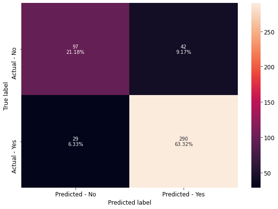

```python
make_confusion_matrix(lda,y_test)
```

```
AUC Training Data for LDA: 0.876
```

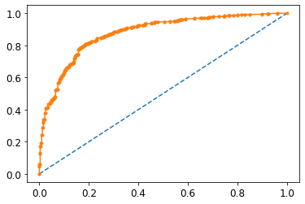

```
AUC Test Data for LDA: 0.915
```

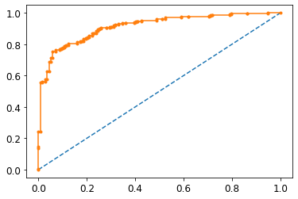

```python
# --------------------------------------------------------------------------------------------------------------------
# predict probabilities
probs_lda = lda.predict_proba(X_train)
# keep probabilities for the positive outcome only
probs_lda = probs_lda[:, 1]
# calculate AUC
auc_lda_train = roc_auc_score(y_train, probs_lda)
print('AUC Training Data for LDA: %.3f' % auc_lda_train)
# calculate ROC
fpr_lda_train, tpr_lda_train, thresholds_lda_train = roc_curve(y_train, probs_lda)
plt.plot([0, 1], [0, 1], linestyle='--')
# plot the roc curve for the model
plt.plot(fpr_lda_train, tpr_lda_train, marker='.')
# show the plot
plt.show()
# --------------------------------------------------------------------------------------------------------------------
# predict probabilities
probs_lda = lda.predict_proba(X_test)
# keep probabilities for the positive outcome only
probs_lda = probs_lda[:, 1]
# calculate AUC
auc_lda_test = roc_auc_score(y_test, probs_lda)
print('AUC Test Data for LDA: %.3f' % auc_lda_test)
# calculate ROC
fpr_lda_test, tpr_lda_test, thresholds_lda_test = roc_curve(y_test, probs_lda)
plt.plot([0, 1], [0, 1], linestyle='--')
# plot the roc curve for the model
plt.plot(fpr_lda_test, tpr_lda_test, marker='.')
# show the plot
plt.show()
```

```python
# defining list of models
models = [lr,lda]

# defining empty lists to add train and test results
acc_train = []
acc_test = []
recall_train = []
recall_test = []
precision_train = []
precision_test = []
f1_train = []
f1_test = []

# looping through all the models to get the accuracy, precall and precision scores
for model in models:
    j = get_metrics_score(model,False)
    acc_train.append(np.round(j[0],2))
    acc_test.append(np.round(j[1],2))
    recall_train.append(np.round(j[2],2))
    recall_test.append(np.round(j[3],2))
    precision_train.append(np.round(j[4],2))
    precision_test.append(np.round(j[5],2))
    f1_train.append(np.round(j[6],2))
    f1_test.append(np.round(j[7],2))
```

```python
model_interpretation_frame = pd.DataFrame({'Model':['Logistic Regression','LDA'],
                                          'Train_Accuracy': acc_train,'Test_Accuracy': acc_test,
                                          'Train_Recall':recall_train,'Test_Recall':recall_test,
                                          'Train_Precision':precision_train,'Test_Precision':precision_test,
                                          'Train_F1 score':f1_train,'Test_F1 score':f1_test})
model_interpretation_frame
```

|  | Model | Train_Accuracy | Test_Accuracy | Train_Recall | Test_Recall | Train_Precision | Test_Precision | Train_F1 score | Test_F1 score |
| --- | --- | --- | --- | --- | --- | --- | --- | --- | --- |
| 0 | Logistic Regression | 0.83 | 0.85 | 0.91 | 0.92 | 0.86 | 0.87 | 0.88 | 0.90 |
| 1 | LDA | 0.83 | 0.84 | 0.90 | 0.91 | 0.86 | 0.87 | 0.88 | 0.89 |

**Intepretation:**

**LDA:**

- Accuracy for train and test is **almost same** (i.e. train: ~83%, test: ~84%)
- Recall for train and test is **almost same** (i.e. train: ~90%, test: ~91%)
- Precision for train and test is **almost same** (i.e. train: ~86%, test: ~87%)
- F1-score for train and test is **almost same** (i.e. train: ~88%, test: ~89%)
- AUC for train and test is **almost same** (i.e. train: ~88%, test: ~92%)

**So, Logistic Regression LDA gave almost the same results**

## Apply KNN Model and Naïve Bayes Model. Interpret the results.

### KNN

```python
from sklearn.neighbors import KNeighborsClassifier
```

```python
knn = KNeighborsClassifier()
knn.fit(X_train, y_train)

train_pred = knn.predict(X_train)
test_pred = knn.predict(X_test)

print('Train Accuracy: {:.0%}'.format(accuracy_score(y_train, train_pred)))
print('Test Accuracy: {:.0%}'.format(accuracy_score(y_test, test_pred)))
print('\n')
print("Train Classification Report")
print('\n')
print(classification_report(y_train, train_pred))
print("Test Classification Report")
print('\n')
print(classification_report(y_test, test_pred))
```

```
Train Accuracy: 86%
Test Accuracy: 84%


Train Classification Report


              precision    recall  f1-score   support

           0       0.78      0.74      0.76       323
           1       0.89      0.91      0.90       744

    accuracy                           0.86      1067
   macro avg       0.84      0.83      0.83      1067
weighted avg       0.86      0.86      0.86      1067

Test Classification Report


              precision    recall  f1-score   support

           0       0.76      0.68      0.72       139
           1       0.87      0.91      0.89       319

    accuracy                           0.84       458
   macro avg       0.81      0.79      0.80       458
weighted avg       0.84      0.84      0.84       458
```

```python
#Using above defined function to get accuracy, recall, precision and F1-score on train and test set
knn_score=get_metrics_score(knn)
```

```
Accuracy on training set :86%
Accuracy on test set : 84%
Recall on training set : 91%
Recall on test set : 91%
Precision on training set : 89%
Precision on test set : 87%
F1 score on training set : 90%
F1 score on test set : 89%
```

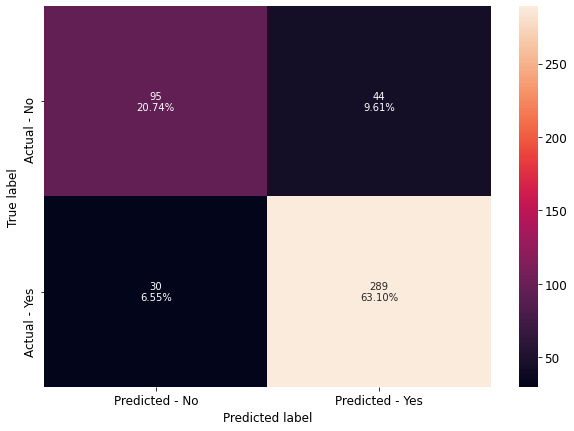

```python
make_confusion_matrix(knn,y_test)
```

```
AUC Training Data for KNN: 0.933
```

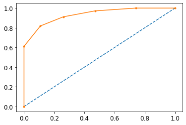

```
AUC Test Data for KNN: 0.877
```

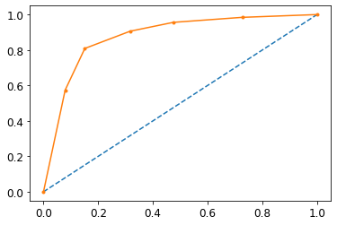

```python
# --------------------------------------------------------------------------------------------------------------------
# predict probabilities
probs_knn = knn.predict_proba(X_train)
# keep probabilities for the positive outcome only
probs_knn = probs_knn[:, 1]
# calculate AUC
auc_knn_train = roc_auc_score(y_train, probs_knn)
print('AUC Training Data for KNN: %.3f' % auc_knn_train)
# calculate ROC
fpr_knn_train, tpr_knn_train, thresholds_knn_train = roc_curve(y_train, probs_knn)
plt.plot([0, 1], [0, 1], linestyle='--')
# plot the roc curve for the model
plt.plot(fpr_knn_train, tpr_knn_train, marker='.')
# show the plot
plt.show()
# --------------------------------------------------------------------------------------------------------------------
# predict probabilities
probs_knn = knn.predict_proba(X_test)
# keep probabilities for the positive outcome only
probs_knn = probs_knn[:, 1]
# calculate AUC
auc_knn_test = roc_auc_score(y_test, probs_knn)
print('AUC Test Data for KNN: %.3f' % auc_knn_test)
# calculate ROC
fpr_knn_test, tpr_knn_test, thresholds_knn_test = roc_curve(y_test, probs_knn)
plt.plot([0, 1], [0, 1], linestyle='--')
# plot the roc curve for the model
plt.plot(fpr_knn_test, tpr_knn_test, marker='.')
# show the plot
plt.show()
```

```python
# defining list of models
models = [lr,lda,knn]

# defining empty lists to add train and test results
acc_train = []
acc_test = []
recall_train = []
recall_test = []
precision_train = []
precision_test = []
f1_train = []
f1_test = []

# looping through all the models to get the accuracy, precall and precision scores
for model in models:
    j = get_metrics_score(model,False)
    acc_train.append(np.round(j[0],2))
    acc_test.append(np.round(j[1],2))
    recall_train.append(np.round(j[2],2))
    recall_test.append(np.round(j[3],2))
    precision_train.append(np.round(j[4],2))
    precision_test.append(np.round(j[5],2))
    f1_train.append(np.round(j[6],2))
    f1_test.append(np.round(j[7],2))
```

```python
model_interpretation_frame = pd.DataFrame({'Model':['Logistic Regression','LDA','KNN'],
                                          'Train_Accuracy': acc_train,'Test_Accuracy': acc_test,
                                          'Train_Recall':recall_train,'Test_Recall':recall_test,
                                          'Train_Precision':precision_train,'Test_Precision':precision_test,
                                          'Train_F1 score':f1_train,'Test_F1 score':f1_test})
model_interpretation_frame
```

|  | Model | Train_Accuracy | Test_Accuracy | Train_Recall | Test_Recall | Train_Precision | Test_Precision | Train_F1 score | Test_F1 score |
| --- | --- | --- | --- | --- | --- | --- | --- | --- | --- |
| 0 | Logistic Regression | 0.83 | 0.85 | 0.91 | 0.92 | 0.86 | 0.87 | 0.88 | 0.90 |
| 1 | LDA | 0.83 | 0.84 | 0.90 | 0.91 | 0.86 | 0.87 | 0.88 | 0.89 |
| 2 | KNN | 0.86 | 0.84 | 0.91 | 0.91 | 0.89 | 0.87 | 0.90 | 0.89 |

**Intepretation:**

**KNN:**

- Accuracy for train and test is **almost same** (i.e. train: ~86%, test: ~84%)
- Recall for train and test is **almost same** (i.e. train: ~91%, test: ~91%)
- Precision for train and test is **almost same** (i.e. train: ~89%, test: ~87%)
- F1-score for train and test is **almost same** (i.e. train: ~90%, test: ~89%)
- AUC for train and test has **slight overfit but managable** (i.e. train: ~93%, test: ~88%)

### Naive Bayes

```python
from sklearn.naive_bayes import GaussianNB # using Gaussian algorithm from Naive Bayes
```

```python
nb = GaussianNB()
nb.fit(X_train, y_train)

train_pred = nb.predict(X_train)
test_pred = nb.predict(X_test)

print('Train Accuracy: {:.0%}'.format(accuracy_score(y_train, train_pred)))
print('Test Accuracy: {:.0%}'.format(accuracy_score(y_test, test_pred)))
print('\n')
print("Train Classification Report")
print('\n')
print(classification_report(y_train, train_pred))
print("Test Classification Report")
print('\n')
print(classification_report(y_test, test_pred))
```

```
Train Accuracy: 82%
Test Accuracy: 85%


Train Classification Report


              precision    recall  f1-score   support

           0       0.71      0.69      0.70       323
           1       0.87      0.88      0.87       744

    accuracy                           0.82      1067
   macro avg       0.79      0.78      0.79      1067
weighted avg       0.82      0.82      0.82      1067

Test Classification Report


              precision    recall  f1-score   support

           0       0.76      0.73      0.74       139
           1       0.88      0.90      0.89       319

    accuracy                           0.85       458
   macro avg       0.82      0.81      0.82       458
weighted avg       0.85      0.85      0.85       458
```

```python
#Using above defined function to get accuracy, recall, precision and F1-score on train and test set
nb_score=get_metrics_score(nb)
```

```
Accuracy on training set :82%
Accuracy on test set : 85%
Recall on training set : 88%
Recall on test set : 90%
Precision on training set : 87%
Precision on test set : 88%
F1 score on training set : 87%
F1 score on test set : 89%
```

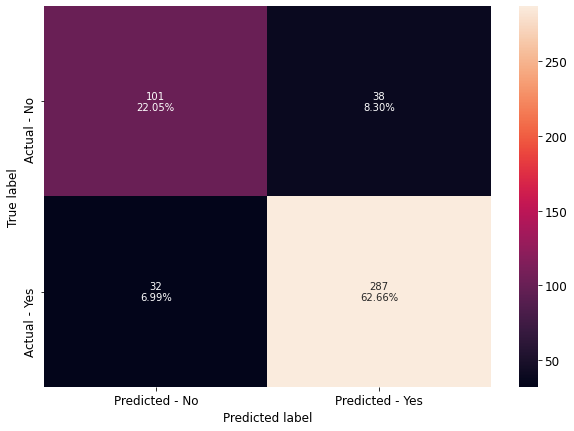

```python
make_confusion_matrix(nb,y_test)
```

```
AUC Training Data for Naive Bayes: 0.874
```

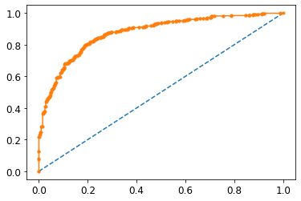

```
AUC Test Data for Naive Bayes: 0.910
```

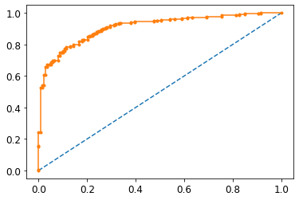

```python
# --------------------------------------------------------------------------------------------------------------------
# predict probabilities
probs_nb = nb.predict_proba(X_train)
# keep probabilities for the positive outcome only
probs_nb = probs_nb[:, 1]
# calculate AUC
auc_nb_train = roc_auc_score(y_train, probs_nb)
print('AUC Training Data for Naive Bayes: %.3f' % auc_nb_train)
# calculate ROC
fpr_nb_train, tpr_nb_train, thresholds_nb_train = roc_curve(y_train, probs_nb)
plt.plot([0, 1], [0, 1], linestyle='--')
# plot the roc curve for the model
plt.plot(fpr_nb_train, tpr_nb_train, marker='.')
# show the plot
plt.show()
# --------------------------------------------------------------------------------------------------------------------
# predict probabilities
probs_nb = nb.predict_proba(X_test)
# keep probabilities for the positive outcome only
probs_nb = probs_nb[:, 1]
# calculate AUC
auc_nb_test = roc_auc_score(y_test, probs_nb)
print('AUC Test Data for Naive Bayes: %.3f' % auc_nb_test)
# calculate ROC
fpr_nb_test, tpr_nb_test, thresholds_nb_test = roc_curve(y_test, probs_nb)
plt.plot([0, 1], [0, 1], linestyle='--')
# plot the roc curve for the model
plt.plot(fpr_nb_test, tpr_nb_test, marker='.')
# show the plot
plt.show()
```

```python
# defining list of models
models = [lr,lda,knn,nb]

# defining empty lists to add train and test results
acc_train = []
acc_test = []
recall_train = []
recall_test = []
precision_train = []
precision_test = []
f1_train = []
f1_test = []

# looping through all the models to get the accuracy, precall and precision scores
for model in models:
    j = get_metrics_score(model,False)
    acc_train.append(np.round(j[0],2))
    acc_test.append(np.round(j[1],2))
    recall_train.append(np.round(j[2],2))
    recall_test.append(np.round(j[3],2))
    precision_train.append(np.round(j[4],2))
    precision_test.append(np.round(j[5],2))
    f1_train.append(np.round(j[6],2))
    f1_test.append(np.round(j[7],2))
```

```python
model_interpretation_frame = pd.DataFrame({'Model':['Logistic Regression','LDA','KNN','Naive Bayes'],
                                          'Train_Accuracy': acc_train,'Test_Accuracy': acc_test,
                                          'Train_Recall':recall_train,'Test_Recall':recall_test,
                                          'Train_Precision':precision_train,'Test_Precision':precision_test,
                                          'Train_F1 score':f1_train,'Test_F1 score':f1_test})
model_interpretation_frame
```

|  | Model | Train_Accuracy | Test_Accuracy | Train_Recall | Test_Recall | Train_Precision | Test_Precision | Train_F1 score | Test_F1 score |
| --- | --- | --- | --- | --- | --- | --- | --- | --- | --- |
| 0 | Logistic Regression | 0.83 | 0.85 | 0.91 | 0.92 | 0.86 | 0.87 | 0.88 | 0.90 |
| 1 | LDA | 0.83 | 0.84 | 0.90 | 0.91 | 0.86 | 0.87 | 0.88 | 0.89 |
| 2 | KNN | 0.86 | 0.84 | 0.91 | 0.91 | 0.89 | 0.87 | 0.90 | 0.89 |
| 3 | Naive Bayes | 0.82 | 0.85 | 0.88 | 0.90 | 0.87 | 0.88 | 0.87 | 0.89 |

**Intepretation:**

**Naive Bayes:**

- Accuracy for train and test is **almost same** (i.e. train: ~82%, test: ~85%)
- Recall for train and test is **almost same** (i.e. train: ~88%, test: ~90%)
- Precision for train and test is **almost same** (i.e. train: ~87%, test: ~88%)
- F1-score for train and test is **almost same** (i.e. train: ~87%, test: ~89%)
- AUC for train and test is **almost same** (i.e. train: ~87%, test: ~91%)

So, Let's go for bagging and bossting models and interpret the results

## Bagging (Random Forest should be applied for Bagging) Model

### Bagging Classifier

```python
from sklearn.ensemble import BaggingClassifier
from sklearn.ensemble import RandomForestClassifier
```

```python
be = RandomForestClassifier()
```

```python
bag = BaggingClassifier(base_estimator= be, n_estimators= 10, random_state=1)
bag.fit(X_train, y_train)

train_pred = bag.predict(X_train)
test_pred = bag.predict(X_test)

print('Train Accuracy: {:.0%}'.format(accuracy_score(y_train, train_pred)))
print('Test Accuracy: {:.0%}'.format(accuracy_score(y_test, test_pred)))
print('\n')
print("Train Classification Report")
print('\n')
print(classification_report(y_train, train_pred))
print("Test Classification Report")
print('\n')
print(classification_report(y_test, test_pred))
```

```
Train Accuracy: 96%
Test Accuracy: 83%


Train Classification Report


              precision    recall  f1-score   support

           0       0.97      0.91      0.94       323
           1       0.96      0.99      0.97       744

    accuracy                           0.96      1067
   macro avg       0.96      0.95      0.96      1067
weighted avg       0.96      0.96      0.96      1067

Test Classification Report


              precision    recall  f1-score   support

           0       0.77      0.64      0.70       139
           1       0.85      0.92      0.89       319

    accuracy                           0.83       458
   macro avg       0.81      0.78      0.79       458
weighted avg       0.83      0.83      0.83       458
```

```python
#Using above defined function to get accuracy, recall, precision and F1-score on train and test set
bag_score=get_metrics_score(bag)
```

```
Accuracy on training set :96%
Accuracy on test set : 83%
Recall on training set : 99%
Recall on test set : 92%
Precision on training set : 96%
Precision on test set : 85%
F1 score on training set : 97%
F1 score on test set : 89%
```

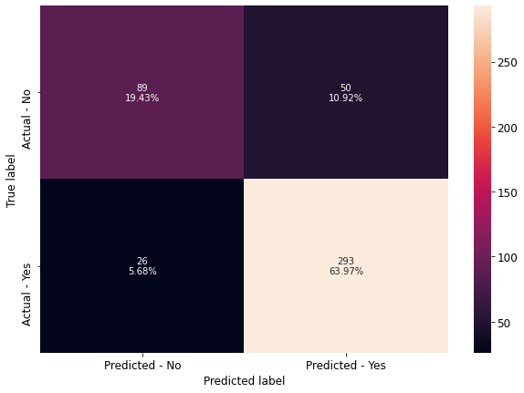

```python
make_confusion_matrix(bag,y_test)
```

```
AUC Training Data for Bagging Classifier: 0.995
```

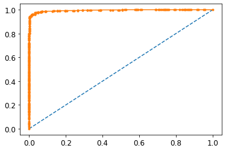

```
AUC Test Data for Bagging Classifier: 0.916
```

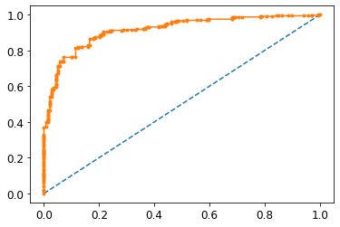

```python
# --------------------------------------------------------------------------------------------------------------------
# predict probabilities
probs_bag = bag.predict_proba(X_train)
# keep probabilities for the positive outcome only
probs_bag = probs_bag[:, 1]
# calculate AUC
auc_bag_train = roc_auc_score(y_train, probs_bag)
print('AUC Training Data for Bagging Classifier: %.3f' % auc_bag_train)
# calculate ROC
fpr_bag_train, tpr_bag_train, thresholds_bag_train = roc_curve(y_train, probs_bag)
plt.plot([0, 1], [0, 1], linestyle='--')
# plot the roc curve for the model
plt.plot(fpr_bag_train, tpr_bag_train, marker='.')
# show the plot
plt.show()
# --------------------------------------------------------------------------------------------------------------------
# predict probabilities
probs_bag = bag.predict_proba(X_test)
# keep probabilities for the positive outcome only
probs_bag = probs_bag[:, 1]
# calculate AUC
auc_bag_test = roc_auc_score(y_test, probs_bag)
print('AUC Test Data for Bagging Classifier: %.3f' % auc_bag_test)
# calculate ROC
fpr_bag_test, tpr_bag_test, thresholds_bag_test = roc_curve(y_test, probs_bag)
plt.plot([0, 1], [0, 1], linestyle='--')
# plot the roc curve for the model
plt.plot(fpr_bag_test, tpr_bag_test, marker='.')
# show the plot
plt.show()
```

```python
# defining list of models
models = [lr,lda,knn,nb,bag]

# defining empty lists to add train and test results
acc_train = []
acc_test = []
recall_train = []
recall_test = []
precision_train = []
precision_test = []
f1_train = []
f1_test = []

# looping through all the models to get the accuracy, precall and precision scores
for model in models:
    j = get_metrics_score(model,False)
    acc_train.append(np.round(j[0],2))
    acc_test.append(np.round(j[1],2))
    recall_train.append(np.round(j[2],2))
    recall_test.append(np.round(j[3],2))
    precision_train.append(np.round(j[4],2))
    precision_test.append(np.round(j[5],2))
    f1_train.append(np.round(j[6],2))
    f1_test.append(np.round(j[7],2))
```

```python
model_interpretation_frame = pd.DataFrame({'Model':['Logistic Regression','LDA','KNN','Naive Bayes','Bagging'],
                                          'Train_Accuracy': acc_train,'Test_Accuracy': acc_test,
                                          'Train_Recall':recall_train,'Test_Recall':recall_test,
                                          'Train_Precision':precision_train,'Test_Precision':precision_test,
                                          'Train_F1 score':f1_train,'Test_F1 score':f1_test})
model_interpretation_frame
```

|  | Model | Train_Accuracy | Test_Accuracy | Train_Recall | Test_Recall | Train_Precision | Test_Precision | Train_F1 score | Test_F1 score |
| --- | --- | --- | --- | --- | --- | --- | --- | --- | --- |
| 0 | Logistic Regression | 0.83 | 0.85 | 0.91 | 0.92 | 0.86 | 0.87 | 0.88 | 0.90 |
| 1 | LDA | 0.83 | 0.84 | 0.90 | 0.91 | 0.86 | 0.87 | 0.88 | 0.89 |
| 2 | KNN | 0.86 | 0.84 | 0.91 | 0.91 | 0.89 | 0.87 | 0.90 | 0.89 |
| 3 | Naive Bayes | 0.82 | 0.85 | 0.88 | 0.90 | 0.87 | 0.88 | 0.87 | 0.89 |
| 4 | Bagging | 0.96 | 0.83 | 0.99 | 0.92 | 0.96 | 0.85 | 0.97 | 0.89 |

**Intepretation:**

**Bagging Classifier(RF as base model):**

- Accuracy for train and test having **overfit of ~13%** (i.e. train: 96%, test: 83%)
- Recall for train and test having **overfit of ~7%** (i.e. train: 99%, test: 92%)
- Precision for train and test having **overfit of ~11%** (i.e. train: 96%, test: 85%)
- F1-score for train and test having **overfit of ~8%** (i.e. train: 97%, test: 89%)
- AUC for train and test is ~100% and ~92% respectively.

**So, it looks like with using RF as base model bagging classifier model gives overfit in all parameter. We need to do model tuning for sure to get rid of overfit.**

## Boosting Models

### Adaboost

```python
from sklearn.ensemble import AdaBoostClassifier
```

```python
ada = AdaBoostClassifier(n_estimators= 100, random_state=1, learning_rate=0.1)
ada.fit(X_train, y_train)

train_pred = ada.predict(X_train)
test_pred = ada.predict(X_test)

print('Train Accuracy: {:.0%}'.format(accuracy_score(y_train, train_pred)))
print('Test Accuracy: {:.0%}'.format(accuracy_score(y_test, test_pred)))
print('\n')
print("Train Classification Report")
print('\n')
print(classification_report(y_train, train_pred))
print("Test Classification Report")
print('\n')
print(classification_report(y_test, test_pred))
```

```
Train Accuracy: 83%
Test Accuracy: 84%


Train Classification Report


              precision    recall  f1-score   support

           0       0.76      0.65      0.70       323
           1       0.86      0.91      0.88       744

    accuracy                           0.83      1067
   macro avg       0.81      0.78      0.79      1067
weighted avg       0.83      0.83      0.83      1067

Test Classification Report


              precision    recall  f1-score   support

           0       0.79      0.64      0.71       139
           1       0.86      0.93      0.89       319

    accuracy                           0.84       458
   macro avg       0.83      0.78      0.80       458
weighted avg       0.84      0.84      0.84       458
```

```python
#Using above defined function to get accuracy, recall, precision and F1-score on train and test set
ada_score=get_metrics_score(ada)
```

```
Accuracy on training set :83%
Accuracy on test set : 84%
Recall on training set : 91%
Recall on test set : 93%
Precision on training set : 86%
Precision on test set : 86%
F1 score on training set : 88%
F1 score on test set : 89%
```

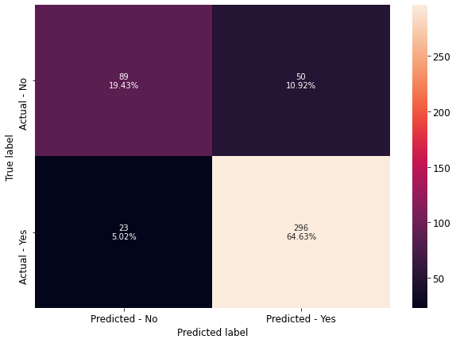

```python
make_confusion_matrix(ada,y_test)
```

```
AUC Training Data for AdaBoost: 0.891
```

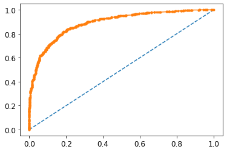

```
AUC Test Data for AdaBoost: 0.905
```

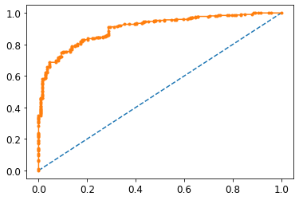

```python
# --------------------------------------------------------------------------------------------------------------------
# predict probabilities
probs_ada = ada.predict_proba(X_train)
# keep probabilities for the positive outcome only
probs_ada = probs_ada[:, 1]
# calculate AUC
auc_ada_train = roc_auc_score(y_train, probs_ada)
print('AUC Training Data for AdaBoost: %.3f' % auc_ada_train)
# calculate ROC
fpr_ada_train, tpr_ada_train, thresholds_ada_train = roc_curve(y_train, probs_ada)
plt.plot([0, 1], [0, 1], linestyle='--')
# plot the roc curve for the model
plt.plot(fpr_ada_train, tpr_ada_train, marker='.')
# show the plot
plt.show()
# --------------------------------------------------------------------------------------------------------------------
# predict probabilities
probs_ada = ada.predict_proba(X_test)
# keep probabilities for the positive outcome only
probs_ada = probs_ada[:, 1]
# calculate AUC
auc_ada_test = roc_auc_score(y_test, probs_ada)
print('AUC Test Data for AdaBoost: %.3f' % auc_ada_test)
# calculate ROC
fpr_ada_test, tpr_ada_test, thresholds_ada_test = roc_curve(y_test, probs_ada)
plt.plot([0, 1], [0, 1], linestyle='--')
# plot the roc curve for the model
plt.plot(fpr_ada_test, tpr_ada_test, marker='.')
# show the plot
plt.show()
```

```python
# defining list of models
models = [lr,lda,knn,nb,bag,ada]

# defining empty lists to add train and test results
acc_train = []
acc_test = []
recall_train = []
recall_test = []
precision_train = []
precision_test = []
f1_train = []
f1_test = []

# looping through all the models to get the accuracy, precall and precision scores
for model in models:
    j = get_metrics_score(model,False)
    acc_train.append(np.round(j[0],2))
    acc_test.append(np.round(j[1],2))
    recall_train.append(np.round(j[2],2))
    recall_test.append(np.round(j[3],2))
    precision_train.append(np.round(j[4],2))
    precision_test.append(np.round(j[5],2))
    f1_train.append(np.round(j[6],2))
    f1_test.append(np.round(j[7],2))
```

```python
model_interpretation_frame = pd.DataFrame({'Model':['Logistic Regression','LDA','KNN','Naive Bayes','Bagging','AdaBoost'],
                                          'Train_Accuracy': acc_train,'Test_Accuracy': acc_test,
                                          'Train_Recall':recall_train,'Test_Recall':recall_test,
                                          'Train_Precision':precision_train,'Test_Precision':precision_test,
                                          'Train_F1 score':f1_train,'Test_F1 score':f1_test})
model_interpretation_frame
```

|  | Model | Train_Accuracy | Test_Accuracy | Train_Recall | Test_Recall | Train_Precision | Test_Precision | Train_F1 score | Test_F1 score |
| --- | --- | --- | --- | --- | --- | --- | --- | --- | --- |
| 0 | Logistic Regression | 0.83 | 0.85 | 0.91 | 0.92 | 0.86 | 0.87 | 0.88 | 0.90 |
| 1 | LDA | 0.83 | 0.84 | 0.90 | 0.91 | 0.86 | 0.87 | 0.88 | 0.89 |
| 2 | KNN | 0.86 | 0.84 | 0.91 | 0.91 | 0.89 | 0.87 | 0.90 | 0.89 |
| 3 | Naive Bayes | 0.82 | 0.85 | 0.88 | 0.90 | 0.87 | 0.88 | 0.87 | 0.89 |
| 4 | Bagging | 0.96 | 0.83 | 0.99 | 0.92 | 0.96 | 0.85 | 0.97 | 0.89 |
| 5 | AdaBoost | 0.83 | 0.84 | 0.91 | 0.93 | 0.86 | 0.86 | 0.88 | 0.89 |

**Intepretation:**

**Adaboost:**

- Accuracy for train and test is **almost same** (i.e. train: ~83%, test: ~84%)
- Recall for train and test is **almost same** (i.e. train: ~91%, test: ~93%)
- Precision for train and test is **same** (i.e. train: ~86%, test: ~86%)
- F1-score for train and test is **almost same** (i.e. train: ~88%, test: ~89%)
- AUC for train and test is **almost same** (i.e. train: ~89%, test: ~91%)

### Gradient Boosting

```python
from sklearn.ensemble import GradientBoostingClassifier
```

```python
gbc = GradientBoostingClassifier(n_estimators= 100, random_state=1)
gbc.fit(X_train, y_train)

train_pred = gbc.predict(X_train)
test_pred = gbc.predict(X_test)

print('Train Accuracy: {:.0%}'.format(accuracy_score(y_train, train_pred)))
print('Test Accuracy: {:.0%}'.format(accuracy_score(y_test, test_pred)))
print('\n')
print("Train Classification Report")
print('\n')
print(classification_report(y_train, train_pred))
print("Test Classification Report")
print('\n')
print(classification_report(y_test, test_pred))
```

```
Train Accuracy: 89%
Test Accuracy: 84%


Train Classification Report


              precision    recall  f1-score   support

           0       0.85      0.76      0.80       323
           1       0.90      0.94      0.92       744

    accuracy                           0.89      1067
   macro avg       0.88      0.85      0.86      1067
weighted avg       0.89      0.89      0.89      1067

Test Classification Report


              precision    recall  f1-score   support

           0       0.77      0.66      0.71       139
           1       0.86      0.91      0.89       319

    accuracy                           0.84       458
   macro avg       0.81      0.79      0.80       458
weighted avg       0.83      0.84      0.83       458
```

```python
#Using above defined function to get accuracy, recall, precision and F1-score on train and test set
gbc_score=get_metrics_score(gbc)
```

```
Accuracy on training set :89%
Accuracy on test set : 84%
Recall on training set : 94%
Recall on test set : 91%
Precision on training set : 90%
Precision on test set : 86%
F1 score on training set : 92%
F1 score on test set : 89%
```

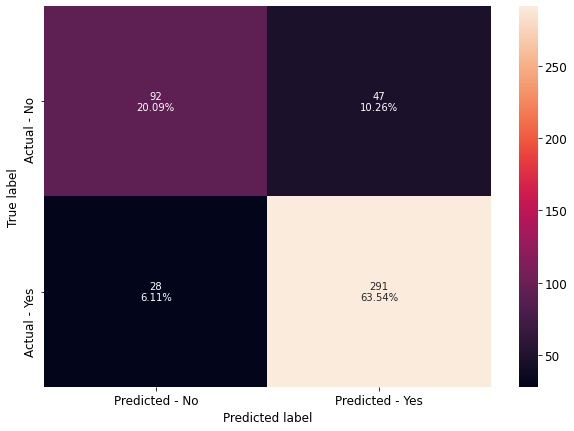

```python
make_confusion_matrix(gbc,y_test)
```

```
AUC Training Data for Gradient Boosting: 0.948
```

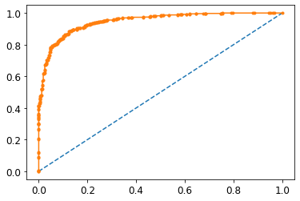

```
AUC Test Data for Gradient Boosting: 0.908
```

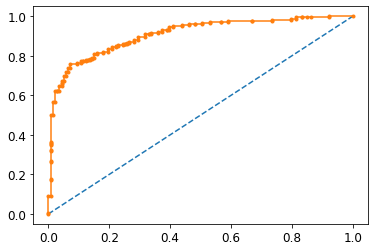

```python
# --------------------------------------------------------------------------------------------------------------------
# predict probabilities
probs_gbc = gbc.predict_proba(X_train)
# keep probabilities for the positive outcome only
probs_gbc = probs_gbc[:, 1]
# calculate AUC
auc_gbc_train = roc_auc_score(y_train, probs_gbc)
print('AUC Training Data for Gradient Boosting: %.3f' % auc_gbc_train)
# calculate ROC
fpr_gbc_train, tpr_gbc_train, thresholds_gbc_train = roc_curve(y_train, probs_gbc)
plt.plot([0, 1], [0, 1], linestyle='--')
# plot the roc curve for the model
plt.plot(fpr_gbc_train, tpr_gbc_train, marker='.')
# show the plot
plt.show()
# --------------------------------------------------------------------------------------------------------------------
# predict probabilities
probs_gbc = gbc.predict_proba(X_test)
# keep probabilities for the positive outcome only
probs_gbc = probs_gbc[:, 1]
# calculate AUC
auc_gbc_test = roc_auc_score(y_test, probs_gbc)
print('AUC Test Data for Gradient Boosting: %.3f' % auc_gbc_test)
# calculate ROC
fpr_gbc_test, tpr_gbc_test, thresholds_gbc_test = roc_curve(y_test, probs_gbc)
plt.plot([0, 1], [0, 1], linestyle='--')
# plot the roc curve for the model
plt.plot(fpr_gbc_test, tpr_gbc_test, marker='.')
# show the plot
plt.show()
```

```python
# defining list of models
models = [lr,lda,knn,nb,bag,ada,gbc]

# defining empty lists to add train and test results
acc_train = []
acc_test = []
recall_train = []
recall_test = []
precision_train = []
precision_test = []
f1_train = []
f1_test = []

# looping through all the models to get the accuracy, precall and precision scores
for model in models:
    j = get_metrics_score(model,False)
    acc_train.append(np.round(j[0],2))
    acc_test.append(np.round(j[1],2))
    recall_train.append(np.round(j[2],2))
    recall_test.append(np.round(j[3],2))
    precision_train.append(np.round(j[4],2))
    precision_test.append(np.round(j[5],2))
    f1_train.append(np.round(j[6],2))
    f1_test.append(np.round(j[7],2))
```

```python
model_interpretation_frame = pd.DataFrame({'Model':['Logistic Regression','LDA','KNN','Naive Bayes','Bagging','AdaBoost','Gradient Boosting'],
                                          'Train_Accuracy': acc_train,'Test_Accuracy': acc_test,
                                          'Train_Recall':recall_train,'Test_Recall':recall_test,
                                          'Train_Precision':precision_train,'Test_Precision':precision_test,
                                          'Train_F1 score':f1_train,'Test_F1 score':f1_test})
model_interpretation_frame
```

|  | Model | Train_Accuracy | Test_Accuracy | Train_Recall | Test_Recall | Train_Precision | Test_Precision | Train_F1 score | Test_F1 score |
| --- | --- | --- | --- | --- | --- | --- | --- | --- | --- |
| 0 | Logistic Regression | 0.83 | 0.85 | 0.91 | 0.92 | 0.86 | 0.87 | 0.88 | 0.90 |
| 1 | LDA | 0.83 | 0.84 | 0.90 | 0.91 | 0.86 | 0.87 | 0.88 | 0.89 |
| 2 | KNN | 0.86 | 0.84 | 0.91 | 0.91 | 0.89 | 0.87 | 0.90 | 0.89 |
| 3 | Naive Bayes | 0.82 | 0.85 | 0.88 | 0.90 | 0.87 | 0.88 | 0.87 | 0.89 |
| 4 | Bagging | 0.96 | 0.83 | 0.99 | 0.92 | 0.96 | 0.85 | 0.97 | 0.89 |
| 5 | AdaBoost | 0.83 | 0.84 | 0.91 | 0.93 | 0.86 | 0.86 | 0.88 | 0.89 |
| 6 | Gradient Boosting | 0.89 | 0.84 | 0.94 | 0.91 | 0.90 | 0.86 | 0.92 | 0.89 |

**Intepretation:**

**Gradient boosting:**

- Accuracy for train and test having **slight overfit** (i.e. train: ~89%, test: ~84%)
- Recall for train and test is **almost same** (i.e. train: ~94%, test: ~91%)
- Precision for train and test is **almost same** (i.e. train: ~90%, test: ~86%)
- F1-score for train and test is **almost same** (i.e. train: ~92%, test: ~89%)
- AUC for train and test is **almost same** (i.e. train: ~95%, test: ~91%)

### XGboost

```python
from xgboost import XGBClassifier
```

```python
xgb = XGBClassifier(random_state=1)
xgb.fit(X_train, y_train)

train_pred = xgb.predict(X_train)
test_pred = xgb.predict(X_test)

print('Train Accuracy: {:.0%}'.format(accuracy_score(y_train, train_pred)))
print('Test Accuracy: {:.0%}'.format(accuracy_score(y_test, test_pred)))
print('\n')
print("Train Classification Report")
print('\n')
print(classification_report(y_train, train_pred))
print("Test Classification Report")
print('\n')
print(classification_report(y_test, test_pred))
```

```
[10:12:23] WARNING: C:/Users/Administrator/workspace/xgboost-win64_release_1.4.0/src/learner.cc:1095: Starting in XGBoost 1.3.0, the default evaluation metric used with the objective 'binary:logistic' was changed from 'error' to 'logloss'. Explicitly set eval_metric if you'd like to restore the old …
Train Accuracy: 99%
Test Accuracy: 83%


Train Classification Report


              precision    recall  f1-score   support

           0       0.99      0.98      0.98       323
           1       0.99      1.00      0.99       744

    accuracy                           0.99      1067
   macro avg       0.99      0.99      0.99      1067
weighted avg       0.99      0.99      0.99      1067

Test Classification Report


              precision    recall  f1-score   support

           0       0.74      0.65      0.69       139
           1       0.86      0.90      0.88       319

    accuracy                           0.83       458
   macro avg       0.80      0.78      0.79       458
weighted avg       0.82      0.83      0.82       458
```

```python
#Using above defined function to get accuracy, recall, precision and F1-score on train and test set
xgb_score=get_metrics_score(xgb)
```

```
Accuracy on training set :99%
Accuracy on test set : 83%
Recall on training set : 100%
Recall on test set : 90%
Precision on training set : 99%
Precision on test set : 86%
F1 score on training set : 99%
F1 score on test set : 88%
```

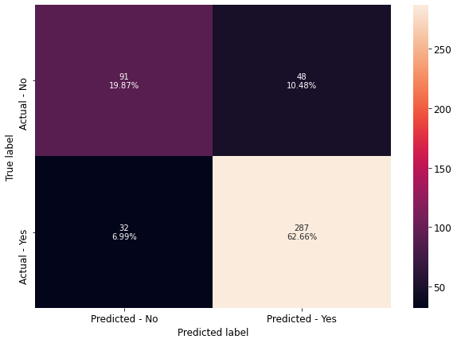

```python
make_confusion_matrix(xgb,y_test)
```

```
AUC Training Data for XGBoost: 0.999
```

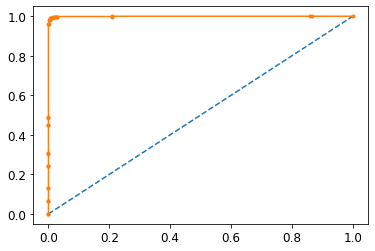

```
AUC Test Data for XGBoost: 0.881
```

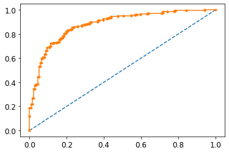

```python
# --------------------------------------------------------------------------------------------------------------------
# predict probabilities
probs_xgb = xgb.predict_proba(X_train)
# keep probabilities for the positive outcome only
probs_xgb = probs_xgb[:, 1]
# calculate AUC
auc_xgb_train = roc_auc_score(y_train, probs_xgb)
print('AUC Training Data for XGBoost: %.3f' % auc_xgb_train)
# calculate ROC
fpr_xgb_train, tpr_xgb_train, thresholds_xgb_train = roc_curve(y_train, probs_xgb)
plt.plot([0, 1], [0, 1], linestyle='--')
# plot the roc curve for the model
plt.plot(fpr_xgb_train, tpr_xgb_train, marker='.')
# show the plot
plt.show()
# --------------------------------------------------------------------------------------------------------------------
# predict probabilities
probs_xgb = xgb.predict_proba(X_test)
# keep probabilities for the positive outcome only
probs_xgb = probs_xgb[:, 1]
# calculate AUC
auc_xgb_test = roc_auc_score(y_test, probs_xgb)
print('AUC Test Data for XGBoost: %.3f' % auc_xgb_test)
# calculate ROC
fpr_xgb_test, tpr_xgb_test, thresholds_xgb_test = roc_curve(y_test, probs_xgb)
plt.plot([0, 1], [0, 1], linestyle='--')
# plot the roc curve for the model
plt.plot(fpr_xgb_test, tpr_xgb_test, marker='.')
# show the plot
plt.show()
```

```python
# defining list of models
models = [lr,lda,knn,nb,bag,ada,gbc,xgb]

# defining empty lists to add train and test results
acc_train = []
acc_test = []
recall_train = []
recall_test = []
precision_train = []
precision_test = []
f1_train = []
f1_test = []

# looping through all the models to get the accuracy, precall and precision scores
for model in models:
    j = get_metrics_score(model,False)
    acc_train.append(np.round(j[0],2))
    acc_test.append(np.round(j[1],2))
    recall_train.append(np.round(j[2],2))
    recall_test.append(np.round(j[3],2))
    precision_train.append(np.round(j[4],2))
    precision_test.append(np.round(j[5],2))
    f1_train.append(np.round(j[6],2))
    f1_test.append(np.round(j[7],2))
```

```python
model_interpretation_frame = pd.DataFrame({'Model':['Logistic Regression','LDA','KNN','Naive Bayes','Bagging',
                                                    'AdaBoost','Gradient Boosting','XGBoost'],
                                          'Train_Accuracy': acc_train,'Test_Accuracy': acc_test,
                                          'Train_Recall':recall_train,'Test_Recall':recall_test,
                                          'Train_Precision':precision_train,'Test_Precision':precision_test,
                                          'Train_F1 score':f1_train,'Test_F1 score':f1_test})
model_interpretation_frame
```

|  | Model | Train_Accuracy | Test_Accuracy | Train_Recall | Test_Recall | Train_Precision | Test_Precision | Train_F1 score | Test_F1 score |
| --- | --- | --- | --- | --- | --- | --- | --- | --- | --- |
| 0 | Logistic Regression | 0.83 | 0.85 | 0.91 | 0.92 | 0.86 | 0.87 | 0.88 | 0.90 |
| 1 | LDA | 0.83 | 0.84 | 0.90 | 0.91 | 0.86 | 0.87 | 0.88 | 0.89 |
| 2 | KNN | 0.86 | 0.84 | 0.91 | 0.91 | 0.89 | 0.87 | 0.90 | 0.89 |
| 3 | Naive Bayes | 0.82 | 0.85 | 0.88 | 0.90 | 0.87 | 0.88 | 0.87 | 0.89 |
| 4 | Bagging | 0.96 | 0.83 | 0.99 | 0.92 | 0.96 | 0.85 | 0.97 | 0.89 |
| 5 | AdaBoost | 0.83 | 0.84 | 0.91 | 0.93 | 0.86 | 0.86 | 0.88 | 0.89 |
| 6 | Gradient Boosting | 0.89 | 0.84 | 0.94 | 0.91 | 0.90 | 0.86 | 0.92 | 0.89 |
| 7 | XGBoost | 0.99 | 0.83 | 1.00 | 0.90 | 0.99 | 0.86 | 0.99 | 0.88 |

**Intepretation:**

**XGBoost:**

- Accuracy for train and test having **overfit of ~16%** (i.e. train: ~99%, test: ~83%)
- Recall for train and test having **overfit of ~10%** (i.e. train: ~100%, test: ~90%)
- Precision for train and test having **overfit of ~13%** (i.e. train: ~99%, test: ~86%)
- F1-score for train and test having **overfit of ~11%** (i.e. train: ~99%, test: ~88%)
- AUC for train and test is ~100% and ~88% respectively.

we have good amount of overfit with default parameter of XGBoost. Model tunning would be helpful to get rid of the same.

### SVM (Support Vector Machine)

**Support vector machines (SVMs) are a set of supervised learning methods used for classification, regression and outliers detection**

**The advantages of support vector machines are:**

- Effective in high dimensional spaces.
- Still effective in cases where number of dimensions is greater than the number of samples.
- Uses a subset of training points in the decision function (called support vectors), so it is also memory efficient.
- Versatile: different Kernel functions can be specified for the decision function. Common kernels are provided, but it is also possible to specify custom kernels.

```python
from sklearn import svm
```

```python
svm_model = svm.SVC(random_state=1,probability=True)
svm_model.fit(X_train, y_train)

train_pred = svm_model.predict(X_train)
test_pred = svm_model.predict(X_test)

print('Train Accuracy: {:.0%}'.format(accuracy_score(y_train, train_pred)))
print('Test Accuracy: {:.0%}'.format(accuracy_score(y_test, test_pred)))
print('\n')
print("Train Classification Report")
print('\n')
print(classification_report(y_train, train_pred))
print("Test Classification Report")
print('\n')
print(classification_report(y_test, test_pred))
```

```
Train Accuracy: 83%
Test Accuracy: 85%


Train Classification Report


              precision    recall  f1-score   support

           0       0.77      0.64      0.70       323
           1       0.86      0.92      0.89       744

    accuracy                           0.83      1067
   macro avg       0.81      0.78      0.79      1067
weighted avg       0.83      0.83      0.83      1067

Test Classification Report


              precision    recall  f1-score   support

           0       0.82      0.67      0.74       139
           1       0.87      0.93      0.90       319

    accuracy                           0.85       458
   macro avg       0.84      0.80      0.82       458
weighted avg       0.85      0.85      0.85       458
```

```python
#Using above defined function to get accuracy, recall, precision and F1-score on train and test set
svm_score=get_metrics_score(svm_model)
```

```
Accuracy on training set :83%
Accuracy on test set : 85%
Recall on training set : 92%
Recall on test set : 93%
Precision on training set : 86%
Precision on test set : 87%
F1 score on training set : 89%
F1 score on test set : 90%
```

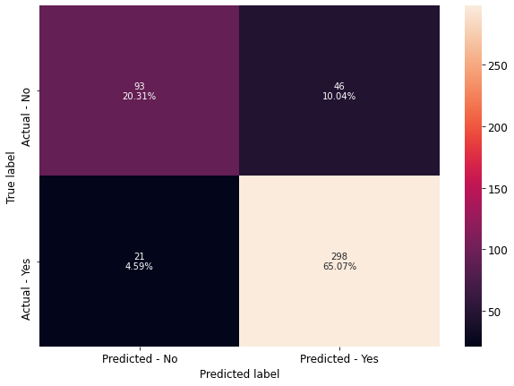

```python
make_confusion_matrix(svm_model,y_test)
```

```
AUC Training Data for SVM: 0.898
```

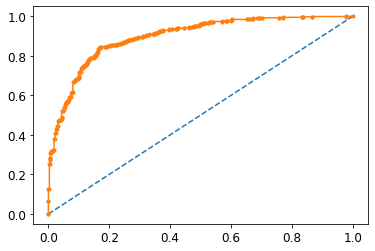

```
AUC Test Data for SVM: 0.915
```

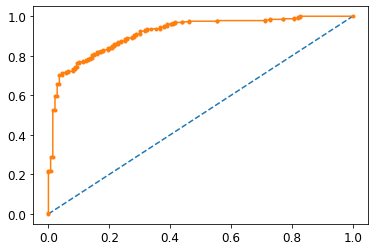

```python
# --------------------------------------------------------------------------------------------------------------------
# predict probabilities
probs_svm = svm_model.predict_proba(X_train)
# keep probabilities for the positive outcome only
probs_svm = probs_svm[:, 1]
# calculate AUC
auc_svm_train = roc_auc_score(y_train, probs_svm)
print('AUC Training Data for SVM: %.3f' % auc_svm_train)
# calculate ROC
fpr_svm_train, tpr_svm_train, thresholds_svm_train = roc_curve(y_train, probs_svm)
plt.plot([0, 1], [0, 1], linestyle='--')
# plot the roc curve for the model
plt.plot(fpr_svm_train, tpr_svm_train, marker='.')
# show the plot
plt.show()
# --------------------------------------------------------------------------------------------------------------------
# predict probabilities
probs_svm = svm_model.predict_proba(X_test)
# keep probabilities for the positive outcome only
probs_svm = probs_svm[:, 1]
# calculate AUC
auc_svm_test = roc_auc_score(y_test, probs_svm)
print('AUC Test Data for SVM: %.3f' % auc_svm_test)
# calculate ROC
fpr_svm_test, tpr_svm_test, thresholds_svm_test = roc_curve(y_test, probs_svm)
plt.plot([0, 1], [0, 1], linestyle='--')
# plot the roc curve for the model
plt.plot(fpr_svm_test, tpr_svm_test, marker='.')
# show the plot
plt.show()
```

```python
# defining list of models
models = [lr,lda,knn,nb,bag,ada,gbc,xgb,svm_model]

# defining empty lists to add train and test results
acc_train = []
acc_test = []
recall_train = []
recall_test = []
precision_train = []
precision_test = []
f1_train = []
f1_test = []

# looping through all the models to get the accuracy, precall and precision scores
for model in models:
    j = get_metrics_score(model,False)
    acc_train.append(np.round(j[0],2))
    acc_test.append(np.round(j[1],2))
    recall_train.append(np.round(j[2],2))
    recall_test.append(np.round(j[3],2))
    precision_train.append(np.round(j[4],2))
    precision_test.append(np.round(j[5],2))
    f1_train.append(np.round(j[6],2))
    f1_test.append(np.round(j[7],2))
```

```python
model_interpretation_frame = pd.DataFrame({'Model':['Logistic Regression','LDA','KNN','Naive Bayes','Bagging',
                                                    'AdaBoost','Gradient Boosting','XGBoost','Support Vector Machine(SVM)'],
                                          'Train_Accuracy': acc_train,'Test_Accuracy': acc_test,
                                          'Train_Recall':recall_train,'Test_Recall':recall_test,
                                          'Train_Precision':precision_train,'Test_Precision':precision_test,
                                          'Train_F1 score':f1_train,'Test_F1 score':f1_test})
model_interpretation_frame
```

|  | Model | Train_Accuracy | Test_Accuracy | Train_Recall | Test_Recall | Train_Precision | Test_Precision | Train_F1 score | Test_F1 score |
| --- | --- | --- | --- | --- | --- | --- | --- | --- | --- |
| 0 | Logistic Regression | 0.83 | 0.85 | 0.91 | 0.92 | 0.86 | 0.87 | 0.88 | 0.90 |
| 1 | LDA | 0.83 | 0.84 | 0.90 | 0.91 | 0.86 | 0.87 | 0.88 | 0.89 |
| 2 | KNN | 0.86 | 0.84 | 0.91 | 0.91 | 0.89 | 0.87 | 0.90 | 0.89 |
| 3 | Naive Bayes | 0.82 | 0.85 | 0.88 | 0.90 | 0.87 | 0.88 | 0.87 | 0.89 |
| 4 | Bagging | 0.96 | 0.83 | 0.99 | 0.92 | 0.96 | 0.85 | 0.97 | 0.89 |
| 5 | AdaBoost | 0.83 | 0.84 | 0.91 | 0.93 | 0.86 | 0.86 | 0.88 | 0.89 |
| 6 | Gradient Boosting | 0.89 | 0.84 | 0.94 | 0.91 | 0.90 | 0.86 | 0.92 | 0.89 |
| 7 | XGBoost | 0.99 | 0.83 | 1.00 | 0.90 | 0.99 | 0.86 | 0.99 | 0.88 |
| 8 | Support Vector Machine(SVM) | 0.83 | 0.85 | 0.92 | 0.93 | 0.86 | 0.87 | 0.89 | 0.90 |

**Intepretation:**

**Support Vector Machine (SVM):**

- Accuracy for train and test is **almost same** (i.e. train: ~83%, test: ~85%)
- Recall for train and test is **almost same** (i.e. train: ~92%, test: ~93%)
- Precision for train and test is **almost same** (i.e. train: ~86%, test: ~87%)
- F1-score for train and test having **almost same** (i.e. train: ~89%, test: ~90%)
- AUC for train and test is **almost same** (i.e. train: ~89%, test: ~92%)

## Model Tuning

```python
from sklearn.model_selection import GridSearchCV
```

### Logistic Regression (Model Tuning)

```python
# define models and parameters
model = LogisticRegression(random_state=1)
solvers = ['newton-cg', 'lbfgs', 'liblinear','sag','saga']
penalty = ['l2']
c_values = [100, 10, 1.0, 0.1, 0.01]

# define grid
grid = dict(solver=solvers,penalty=penalty,C=c_values)


# define grid search
grid_search_lr = GridSearchCV(estimator=model, param_grid=grid, n_jobs=-1, cv=5)
grid_search_lr.fit(X_train, y_train)
```

```
GridSearchCV(cv=5, estimator=LogisticRegression(random_state=1), n_jobs=-1,
             param_grid={'C': [100, 10, 1.0, 0.1, 0.01], 'penalty': ['l2'],
                         'solver': ['newton-cg', 'lbfgs', 'liblinear', 'sag',
                                    'saga']})
```

```python
grid_search_lr.best_params_
```

```
{'C': 100, 'penalty': 'l2', 'solver': 'saga'}
```

```python
best_grid_lr = grid_search_lr.best_estimator_
```

```python
train_pred = best_grid_lr.predict(X_train)
test_pred = best_grid_lr.predict(X_test)

print('Train Accuracy: {:.0%}'.format(accuracy_score(y_train, train_pred)))
print('Test Accuracy: {:.0%}'.format(accuracy_score(y_test, test_pred)))
print('\n')
print("Train Classification Report")
print('\n')
print(classification_report(y_train, train_pred))
print("Test Classification Report")
print('\n')
print(classification_report(y_test, test_pred))
```

```
Train Accuracy: 83%
Test Accuracy: 85%


Train Classification Report


              precision    recall  f1-score   support

           0       0.75      0.65      0.70       323
           1       0.86      0.91      0.88       744

    accuracy                           0.83      1067
   macro avg       0.80      0.78      0.79      1067
weighted avg       0.83      0.83      0.83      1067

Test Classification Report


              precision    recall  f1-score   support

           0       0.80      0.68      0.73       139
           1       0.87      0.92      0.90       319

    accuracy                           0.85       458
   macro avg       0.83      0.80      0.81       458
weighted avg       0.85      0.85      0.85       458
```

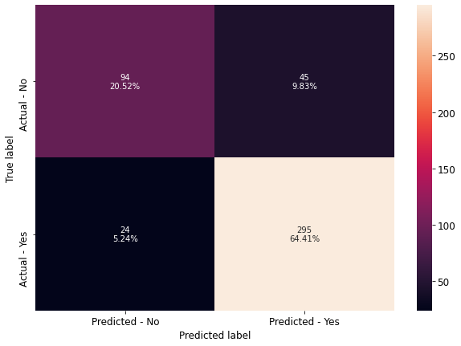

```python
make_confusion_matrix(best_grid_lr,y_test)
```

```
AUC Training Data for Logistic Regression(tuned): 0.877
```

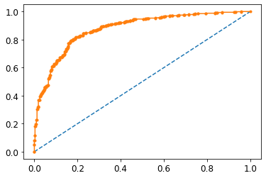

```
AUC Test Data for Logistic Regression(tuned): 0.914
```

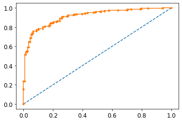

```python
# --------------------------------------------------------------------------------------------------------------------
# predict probabilities
probs_best_grid_lr = best_grid_lr.predict_proba(X_train)
# keep probabilities for the positive outcome only
probs_best_grid_lr = probs_best_grid_lr[:, 1]
# calculate AUC
auc_best_grid_lr_train = roc_auc_score(y_train, probs_best_grid_lr)
print('AUC Training Data for Logistic Regression(tuned): %.3f' % auc_best_grid_lr_train)
# calculate ROC
fpr_best_grid_lr_train, tpr_best_grid_lr_train, thresholds_best_grid_lr_train = roc_curve(y_train, probs_best_grid_lr)
plt.plot([0, 1], [0, 1], linestyle='--')
# plot the roc curve for the model
plt.plot(fpr_best_grid_lr_train, tpr_best_grid_lr_train, marker='.')
# show the plot
plt.show()
# --------------------------------------------------------------------------------------------------------------------
# predict probabilities
probs_best_grid_lr = best_grid_lr.predict_proba(X_test)
# keep probabilities for the positive outcome only
probs_best_grid_lr = probs_best_grid_lr[:, 1]
# calculate AUC
auc_best_grid_lr_test = roc_auc_score(y_test, probs_best_grid_lr)
print('AUC Test Data for Logistic Regression(tuned): %.3f' % auc_best_grid_lr_test)
# calculate ROC
fpr_best_grid_lr_test, tpr_best_grid_lr_test, thresholds_best_grid_lr_test = roc_curve(y_test, probs_best_grid_lr)
plt.plot([0, 1], [0, 1], linestyle='--')
# plot the roc curve for the model
plt.plot(fpr_best_grid_lr_test, tpr_best_grid_lr_test, marker='.')
# show the plot
plt.show()
```

```python
# defining list of models
models = [lr,best_grid_lr]

# defining empty lists to add train and test results
acc_train = []
acc_test = []
recall_train = []
recall_test = []
precision_train = []
precision_test = []
f1_train = []
f1_test = []

# looping through all the models to get the accuracy, precall and precision scores
for model in models:
    j = get_metrics_score(model,False)
    acc_train.append(np.round(j[0],2))
    acc_test.append(np.round(j[1],2))
    recall_train.append(np.round(j[2],2))
    recall_test.append(np.round(j[3],2))
    precision_train.append(np.round(j[4],2))
    precision_test.append(np.round(j[5],2))
    f1_train.append(np.round(j[6],2))
    f1_test.append(np.round(j[7],2))
```

```python
model_interpretation_frame = pd.DataFrame({'Model':['Logistic Regression','Logistic Regression (Tuned)'],
                                          'Train_Accuracy': acc_train,'Test_Accuracy': acc_test,
                                          'Train_Recall':recall_train,'Test_Recall':recall_test,
                                          'Train_Precision':precision_train,'Test_Precision':precision_test,
                                          'Train_F1 score':f1_train,'Test_F1 score':f1_test})
model_interpretation_frame
```

|  | Model | Train_Accuracy | Test_Accuracy | Train_Recall | Test_Recall | Train_Precision | Test_Precision | Train_F1 score | Test_F1 score |
| --- | --- | --- | --- | --- | --- | --- | --- | --- | --- |
| 0 | Logistic Regression | 0.83 | 0.85 | 0.91 | 0.92 | 0.86 | 0.87 | 0.88 | 0.9 |
| 1 | Logistic Regression (Tuned) | 0.83 | 0.85 | 0.91 | 0.92 | 0.86 | 0.87 | 0.88 | 0.9 |

**Intepretation:**

**Logistic Regression (Tuned):**

- After model tuning, we don't see any improvement in perfromace metrics.

### LDA (Model Tuning)

```python
# define models and parameters
model = LinearDiscriminantAnalysis()

## Search grid for optimal parameters
lda_param_grid = {"solver" : ['svd', 'lsqr', 'eigen'],
              "tol" : [0.0001,0.0002,0.0003]}


grid_search_lda = GridSearchCV(model, param_grid = lda_param_grid, cv=10,
                     n_jobs= -1, verbose = 1)

grid_search_lda.fit(X_train,y_train)
```

```
Fitting 10 folds for each of 9 candidates, totalling 90 fits
```

```
GridSearchCV(cv=10, estimator=LinearDiscriminantAnalysis(), n_jobs=-1,
             param_grid={'solver': ['svd', 'lsqr', 'eigen'],
                         'tol': [0.0001, 0.0002, 0.0003]},
             verbose=1)
```

```python
grid_search_lda.best_params_
```

```
{'solver': 'svd', 'tol': 0.0001}
```

```python
best_grid_lda = grid_search_lda.best_estimator_
```

```python
train_pred = best_grid_lda.predict(X_train)
test_pred = best_grid_lda.predict(X_test)

print('Train Accuracy: {:.0%}'.format(accuracy_score(y_train, train_pred)))
print('Test Accuracy: {:.0%}'.format(accuracy_score(y_test, test_pred)))
print('\n')
print("Train Classification Report")
print('\n')
print(classification_report(y_train, train_pred))
print("Test Classification Report")
print('\n')
print(classification_report(y_test, test_pred))
```

```
Train Accuracy: 83%
Test Accuracy: 84%


Train Classification Report


              precision    recall  f1-score   support

           0       0.73      0.67      0.70       323
           1       0.86      0.90      0.88       744

    accuracy                           0.83      1067
   macro avg       0.80      0.78      0.79      1067
weighted avg       0.82      0.83      0.82      1067

Test Classification Report


              precision    recall  f1-score   support

           0       0.77      0.70      0.73       139
           1       0.87      0.91      0.89       319

    accuracy                           0.84       458
   macro avg       0.82      0.80      0.81       458
weighted avg       0.84      0.84      0.84       458
```

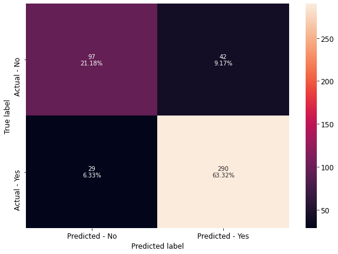

```python
make_confusion_matrix(best_grid_lda,y_test)
```

```
AUC Training Data for LDA(tuned): 0.876
```

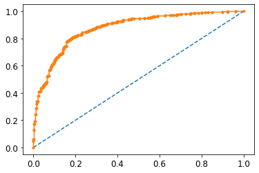

```
AUC Test Data for LDA(tuned): 0.915
```

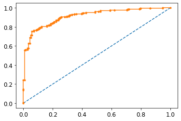

```python
# --------------------------------------------------------------------------------------------------------------------
# predict probabilities
probs_best_grid_lda = best_grid_lda.predict_proba(X_train)
# keep probabilities for the positive outcome only
probs_best_grid_lda = probs_best_grid_lda[:, 1]
# calculate AUC
auc_best_grid_lda_train = roc_auc_score(y_train, probs_best_grid_lda)
print('AUC Training Data for LDA(tuned): %.3f' % auc_best_grid_lda_train)
# calculate ROC
fpr_best_grid_lda_train, tpr_best_grid_lda_train, thresholds_best_grid_lda_train = roc_curve(y_train, probs_best_grid_lda)
plt.plot([0, 1], [0, 1], linestyle='--')
# plot the roc curve for the model
plt.plot(fpr_best_grid_lda_train, tpr_best_grid_lda_train, marker='.')
# show the plot
plt.show()
# --------------------------------------------------------------------------------------------------------------------
# predict probabilities
probs_best_grid_lda = best_grid_lda.predict_proba(X_test)
# keep probabilities for the positive outcome only
probs_best_grid_lda = probs_best_grid_lda[:, 1]
# calculate AUC
auc_best_grid_lda_test = roc_auc_score(y_test, probs_best_grid_lda)
print('AUC Test Data for LDA(tuned): %.3f' % auc_best_grid_lda_test)
# calculate ROC
fpr_best_grid_lda_test, tpr_best_grid_lda_test, thresholds_best_grid_lda_test = roc_curve(y_test, probs_best_grid_lda)
plt.plot([0, 1], [0, 1], linestyle='--')
# plot the roc curve for the model
plt.plot(fpr_best_grid_lda_test, tpr_best_grid_lda_test, marker='.')
# show the plot
plt.show()
```

```python
# defining list of models
models = [lda,best_grid_lda]

# defining empty lists to add train and test results
acc_train = []
acc_test = []
recall_train = []
recall_test = []
precision_train = []
precision_test = []
f1_train = []
f1_test = []

# looping through all the models to get the accuracy, precall and precision scores
for model in models:
    j = get_metrics_score(model,False)
    acc_train.append(np.round(j[0],2))
    acc_test.append(np.round(j[1],2))
    recall_train.append(np.round(j[2],2))
    recall_test.append(np.round(j[3],2))
    precision_train.append(np.round(j[4],2))
    precision_test.append(np.round(j[5],2))
    f1_train.append(np.round(j[6],2))
    f1_test.append(np.round(j[7],2))
```

```python
model_interpretation_frame = pd.DataFrame({'Model':['LDA','LDA (Tuned)'],
                                          'Train_Accuracy': acc_train,'Test_Accuracy': acc_test,
                                          'Train_Recall':recall_train,'Test_Recall':recall_test,
                                          'Train_Precision':precision_train,'Test_Precision':precision_test,
                                          'Train_F1 score':f1_train,'Test_F1 score':f1_test})
model_interpretation_frame
```

|  | Model | Train_Accuracy | Test_Accuracy | Train_Recall | Test_Recall | Train_Precision | Test_Precision | Train_F1 score | Test_F1 score |
| --- | --- | --- | --- | --- | --- | --- | --- | --- | --- |
| 0 | LDA | 0.83 | 0.84 | 0.9 | 0.91 | 0.86 | 0.87 | 0.88 | 0.89 |
| 1 | LDA (Tuned) | 0.83 | 0.84 | 0.9 | 0.91 | 0.86 | 0.87 | 0.88 | 0.89 |

**Intepretation:**

**LDA (Tuned):**

- After model tuning, we don't see any improvement in performance metrics.

### KNN (Model Tuning)

```python
# define models and parameters
model = KNeighborsClassifier()

## Search grid for optimal parameters
knn_param_grid = {'n_neighbors': [1,2,3,5,7,9,11,19],
                  'weights': ['uniform', 'distance'],
                  'metric' :['euclidean','manhattan'],
                  'leaf_size': [1,2,5,10,20,30,50]}


grid_search_knn = GridSearchCV(model, param_grid = knn_param_grid, cv=10,
                     n_jobs= -1, verbose = 1)

grid_search_knn.fit(X_train,y_train)
```

```
Fitting 10 folds for each of 224 candidates, totalling 2240 fits
```

```
GridSearchCV(cv=10, estimator=KNeighborsClassifier(), n_jobs=-1,
             param_grid={'leaf_size': [1, 2, 5, 10, 20, 30, 50],
                         'metric': ['euclidean', 'manhattan'],
                         'n_neighbors': [1, 2, 3, 5, 7, 9, 11, 19],
                         'weights': ['uniform', 'distance']},
             verbose=1)
```

```python
grid_search_knn.best_params_
```

```
{'leaf_size': 20,
 'metric': 'manhattan',
 'n_neighbors': 19,
 'weights': 'uniform'}
```

```python
best_grid_knn = grid_search_knn.best_estimator_
```

```python
train_pred = best_grid_knn.predict(X_train)
test_pred = best_grid_knn.predict(X_test)

print('Train Accuracy: {:.0%}'.format(accuracy_score(y_train, train_pred)))
print('Test Accuracy: {:.0%}'.format(accuracy_score(y_test, test_pred)))
print('\n')
print("Train Classification Report")
print('\n')
print(classification_report(y_train, train_pred))
print("Test Classification Report")
print('\n')
print(classification_report(y_test, test_pred))
```

```
Train Accuracy: 84%
Test Accuracy: 86%


Train Classification Report


              precision    recall  f1-score   support

           0       0.76      0.70      0.72       323
           1       0.87      0.90      0.89       744

    accuracy                           0.84      1067
   macro avg       0.81      0.80      0.81      1067
weighted avg       0.84      0.84      0.84      1067

Test Classification Report


              precision    recall  f1-score   support

           0       0.79      0.72      0.75       139
           1       0.88      0.92      0.90       319

    accuracy                           0.86       458
   macro avg       0.84      0.82      0.83       458
weighted avg       0.86      0.86      0.86       458
```

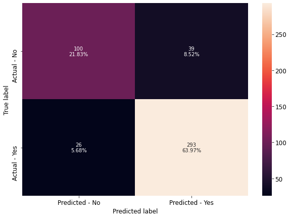

```python
make_confusion_matrix(best_grid_knn,y_test)
```

```
AUC Training Data for KNN(tuned): 0.907
```

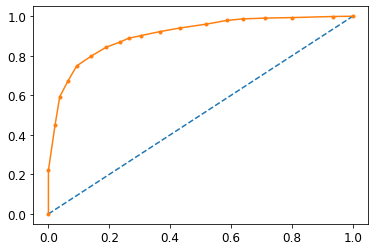

```
AUC Test Data for KNN(tuned): 0.902
```

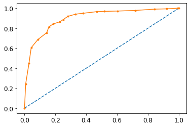

```python
# --------------------------------------------------------------------------------------------------------------------
# predict probabilities
probs_best_grid_knn = best_grid_knn.predict_proba(X_train)
# keep probabilities for the positive outcome only
probs_best_grid_knn = probs_best_grid_knn[:, 1]
# calculate AUC
auc_best_grid_knn_train = roc_auc_score(y_train, probs_best_grid_knn)
print('AUC Training Data for KNN(tuned): %.3f' % auc_best_grid_knn_train)
# calculate ROC
fpr_best_grid_knn_train, tpr_best_grid_knn_train, thresholds_best_grid_knn_train = roc_curve(y_train, probs_best_grid_knn)
plt.plot([0, 1], [0, 1], linestyle='--')
# plot the roc curve for the model
plt.plot(fpr_best_grid_knn_train, tpr_best_grid_knn_train, marker='.')
# show the plot
plt.show()
# --------------------------------------------------------------------------------------------------------------------
# predict probabilities
probs_best_grid_knn = best_grid_knn.predict_proba(X_test)
# keep probabilities for the positive outcome only
probs_best_grid_knn = probs_best_grid_knn[:, 1]
# calculate AUC
auc_best_grid_knn_test = roc_auc_score(y_test, probs_best_grid_knn)
print('AUC Test Data for KNN(tuned): %.3f' % auc_best_grid_knn_test)
# calculate ROC
fpr_best_grid_knn_test, tpr_best_grid_knn_test, thresholds_best_grid_knn_test = roc_curve(y_test, probs_best_grid_knn)
plt.plot([0, 1], [0, 1], linestyle='--')
# plot the roc curve for the model
plt.plot(fpr_best_grid_knn_test, tpr_best_grid_knn_test, marker='.')
# show the plot
plt.show()
```

```python
# defining list of models
models = [knn,best_grid_knn]

# defining empty lists to add train and test results
acc_train = []
acc_test = []
recall_train = []
recall_test = []
precision_train = []
precision_test = []
f1_train = []
f1_test = []

# looping through all the models to get the accuracy, precall and precision scores
for model in models:
    j = get_metrics_score(model,False)
    acc_train.append(np.round(j[0],2))
    acc_test.append(np.round(j[1],2))
    recall_train.append(np.round(j[2],2))
    recall_test.append(np.round(j[3],2))
    precision_train.append(np.round(j[4],2))
    precision_test.append(np.round(j[5],2))
    f1_train.append(np.round(j[6],2))
    f1_test.append(np.round(j[7],2))
```

```python
model_interpretation_frame = pd.DataFrame({'Model':['KNN','KNN (Tuned)'],
                                          'Train_Accuracy': acc_train,'Test_Accuracy': acc_test,
                                          'Train_Recall':recall_train,'Test_Recall':recall_test,
                                          'Train_Precision':precision_train,'Test_Precision':precision_test,
                                          'Train_F1 score':f1_train,'Test_F1 score':f1_test})
model_interpretation_frame
```

|  | Model | Train_Accuracy | Test_Accuracy | Train_Recall | Test_Recall | Train_Precision | Test_Precision | Train_F1 score | Test_F1 score |
| --- | --- | --- | --- | --- | --- | --- | --- | --- | --- |
| 0 | KNN | 0.86 | 0.84 | 0.91 | 0.91 | 0.89 | 0.87 | 0.90 | 0.89 |
| 1 | KNN (Tuned) | 0.84 | 0.86 | 0.90 | 0.92 | 0.87 | 0.88 | 0.89 | 0.90 |

**Intepretation:**

**KNN (Tuned):**

- After model tuning, we got a slight improvement in all performace metrics parameters.

### Naive Bayes (Model Tuning)

```python
# define models and parameters
model = GaussianNB()

## Search grid for optimal parameters
nb_param_grid = {'var_smoothing': np.logspace(0,-9, num=100)}


grid_search_nb = GridSearchCV(model, param_grid = nb_param_grid, cv=10,
                     n_jobs= -1, verbose = 1)

grid_search_nb.fit(X_train,y_train)
```

```
Fitting 10 folds for each of 100 candidates, totalling 1000 fits
```

[output not shown]

```python
grid_search_nb.best_params_
```

```
{'var_smoothing': 0.0023101297000831605}
```

```python
best_grid_nb = grid_search_nb.best_estimator_
```

```python
train_pred = best_grid_nb.predict(X_train)
test_pred = best_grid_nb.predict(X_test)

print('Train Accuracy: {:.0%}'.format(accuracy_score(y_train, train_pred)))
print('Test Accuracy: {:.0%}'.format(accuracy_score(y_test, test_pred)))
print('\n')
print("Train Classification Report")
print('\n')
print(classification_report(y_train, train_pred))
print("Test Classification Report")
print('\n')
print(classification_report(y_test, test_pred))
```

```
Train Accuracy: 82%
Test Accuracy: 84%


Train Classification Report


              precision    recall  f1-score   support

           0       0.71      0.69      0.70       323
           1       0.87      0.88      0.87       744

    accuracy                           0.82      1067
   macro avg       0.79      0.79      0.79      1067
weighted avg       0.82      0.82      0.82      1067

Test Classification Report


              precision    recall  f1-score   support

           0       0.75      0.73      0.74       139
           1       0.88      0.90      0.89       319

    accuracy                           0.84       458
   macro avg       0.82      0.81      0.81       458
weighted avg       0.84      0.84      0.84       458
```

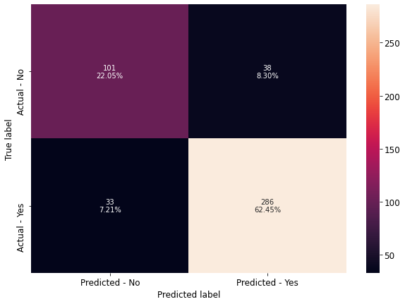

```python
make_confusion_matrix(best_grid_nb,y_test)
```

```
AUC Training Data for Naive Bayes(tuned): 0.874
```

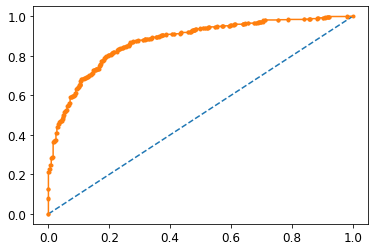

```
AUC Test Data for Naive Bayes(tuned): 0.910
```

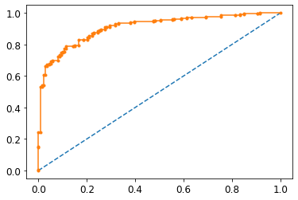

```python
# --------------------------------------------------------------------------------------------------------------------
# predict probabilities
probs_best_grid_nb = best_grid_nb.predict_proba(X_train)
# keep probabilities for the positive outcome only
probs_best_grid_nb = probs_best_grid_nb[:, 1]
# calculate AUC
auc_best_grid_nb_train = roc_auc_score(y_train, probs_best_grid_nb)
print('AUC Training Data for Naive Bayes(tuned): %.3f' % auc_best_grid_nb_train)
# calculate ROC
fpr_best_grid_nb_train, tpr_best_grid_nb_train, thresholds_best_grid_nb_train = roc_curve(y_train, probs_best_grid_nb)
plt.plot([0, 1], [0, 1], linestyle='--')
# plot the roc curve for the model
plt.plot(fpr_best_grid_nb_train, tpr_best_grid_nb_train, marker='.')
# show the plot
plt.show()
# --------------------------------------------------------------------------------------------------------------------
# predict probabilities
probs_best_grid_nb = best_grid_nb.predict_proba(X_test)
# keep probabilities for the positive outcome only
probs_best_grid_nb = probs_best_grid_nb[:, 1]
# calculate AUC
auc_best_grid_nb_test = roc_auc_score(y_test, probs_best_grid_nb)
print('AUC Test Data for Naive Bayes(tuned): %.3f' % auc_best_grid_nb_test)
# calculate ROC
fpr_best_grid_nb_test, tpr_best_grid_nb_test, thresholds_best_grid_nb_test = roc_curve(y_test, probs_best_grid_nb)
plt.plot([0, 1], [0, 1], linestyle='--')
# plot the roc curve for the model
plt.plot(fpr_best_grid_nb_test, tpr_best_grid_nb_test, marker='.')
# show the plot
plt.show()
```

```python
# defining list of models
models = [nb,best_grid_nb]

# defining empty lists to add train and test results
acc_train = []
acc_test = []
recall_train = []
recall_test = []
precision_train = []
precision_test = []
f1_train = []
f1_test = []

# looping through all the models to get the accuracy, precall and precision scores
for model in models:
    j = get_metrics_score(model,False)
    acc_train.append(np.round(j[0],2))
    acc_test.append(np.round(j[1],2))
    recall_train.append(np.round(j[2],2))
    recall_test.append(np.round(j[3],2))
    precision_train.append(np.round(j[4],2))
    precision_test.append(np.round(j[5],2))
    f1_train.append(np.round(j[6],2))
    f1_test.append(np.round(j[7],2))
```

```python
model_interpretation_frame = pd.DataFrame({'Model':['Naive Bayes','Naive Bayes (Tuned)'],
                                          'Train_Accuracy': acc_train,'Test_Accuracy': acc_test,
                                          'Train_Recall':recall_train,'Test_Recall':recall_test,
                                          'Train_Precision':precision_train,'Test_Precision':precision_test,
                                          'Train_F1 score':f1_train,'Test_F1 score':f1_test})
model_interpretation_frame
```

|  | Model | Train_Accuracy | Test_Accuracy | Train_Recall | Test_Recall | Train_Precision | Test_Precision | Train_F1 score | Test_F1 score |
| --- | --- | --- | --- | --- | --- | --- | --- | --- | --- |
| 0 | Naive Bayes | 0.82 | 0.85 | 0.88 | 0.9 | 0.87 | 0.88 | 0.87 | 0.89 |
| 1 | Naive Bayes (Tuned) | 0.82 | 0.84 | 0.88 | 0.9 | 0.87 | 0.88 | 0.87 | 0.89 |

**Intepretation:**

**Naive Bayes (Tuned):**

- After model tuning, we don't see any improvement in performance metrics parameters.

### Bagging (Model Tuning)

```python
# define models and parameters
model = RandomForestClassifier(random_state=1)

## Search grid for optimal parameters
bag_param_grid = {
    'bootstrap': [True],
    'max_depth': [1,2,5,10],
    'max_features': [3,4],
    'min_samples_leaf': [4,5],
    'min_samples_split': [2,4,6],
    'n_estimators': [100, 200, 300]
}


grid_search_bag = GridSearchCV(model, param_grid = bag_param_grid, cv=3,
                     n_jobs= -1, verbose = 1)

grid_search_bag.fit(X_train,y_train)
```

```
Fitting 3 folds for each of 144 candidates, totalling 432 fits
```

```
GridSearchCV(cv=3, estimator=RandomForestClassifier(random_state=1), n_jobs=-1,
             param_grid={'bootstrap': [True], 'max_depth': [1, 2, 5, 10],
                         'max_features': [3, 4], 'min_samples_leaf': [4, 5],
                         'min_samples_split': [2, 4, 6],
                         'n_estimators': [100, 200, 300]},
             verbose=1)
```

```python
grid_search_bag.best_params_
```

```
{'bootstrap': True,
 'max_depth': 5,
 'max_features': 4,
 'min_samples_leaf': 5,
 'min_samples_split': 2,
 'n_estimators': 300}
```

```python
best_grid_bag = grid_search_bag.best_estimator_
```

```python
train_pred = best_grid_bag.predict(X_train)
test_pred = best_grid_bag.predict(X_test)

print('Train Accuracy: {:.0%}'.format(accuracy_score(y_train, train_pred)))
print('Test Accuracy: {:.0%}'.format(accuracy_score(y_test, test_pred)))
print('\n')
print("Train Classification Report")
print('\n')
print(classification_report(y_train, train_pred))
print("Test Classification Report")
print('\n')
print(classification_report(y_test, test_pred))
```

```
Train Accuracy: 87%
Test Accuracy: 85%


Train Classification Report


              precision    recall  f1-score   support

           0       0.80      0.74      0.77       323
           1       0.89      0.92      0.91       744

    accuracy                           0.87      1067
   macro avg       0.85      0.83      0.84      1067
weighted avg       0.86      0.87      0.87      1067

Test Classification Report


              precision    recall  f1-score   support

           0       0.79      0.69      0.74       139
           1       0.87      0.92      0.89       319

    accuracy                           0.85       458
   macro avg       0.83      0.80      0.82       458
weighted avg       0.85      0.85      0.85       458
```

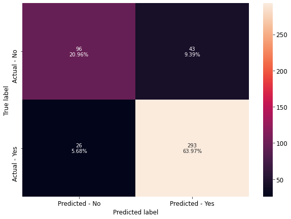

```python
make_confusion_matrix(best_grid_bag,y_test)
```

```
AUC Training Data for Bagging Classifier(tuned): 0.926
```

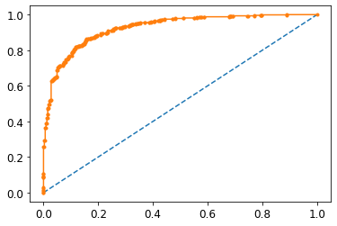

```
AUC Test Data for Bagging Classifier(tuned): 0.912
```

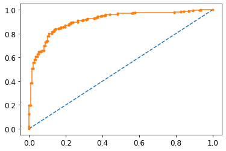

```python
# --------------------------------------------------------------------------------------------------------------------
# predict probabilities
probs_best_grid_bag = best_grid_bag.predict_proba(X_train)
# keep probabilities for the positive outcome only
probs_best_grid_bag = probs_best_grid_bag[:, 1]
# calculate AUC
auc_best_grid_bag_train = roc_auc_score(y_train, probs_best_grid_bag)
print('AUC Training Data for Bagging Classifier(tuned): %.3f' % auc_best_grid_bag_train)
# calculate ROC
fpr_best_grid_bag_train, tpr_best_grid_bag_train, thresholds_best_grid_bag_train = roc_curve(y_train, probs_best_grid_bag)
plt.plot([0, 1], [0, 1], linestyle='--')
# plot the roc curve for the model
plt.plot(fpr_best_grid_bag_train, tpr_best_grid_bag_train, marker='.')
# show the plot
plt.show()
# --------------------------------------------------------------------------------------------------------------------
# predict probabilities
probs_best_grid_bag = best_grid_bag.predict_proba(X_test)
# keep probabilities for the positive outcome only
probs_best_grid_bag = probs_best_grid_bag[:, 1]
# calculate AUC
auc_best_grid_bag_test = roc_auc_score(y_test, probs_best_grid_bag)
print('AUC Test Data for Bagging Classifier(tuned): %.3f' % auc_best_grid_bag_test)
# calculate ROC
fpr_best_grid_bag_test, tpr_best_grid_bag_test, thresholds_best_grid_bag_test = roc_curve(y_test, probs_best_grid_bag)
plt.plot([0, 1], [0, 1], linestyle='--')
# plot the roc curve for the model
plt.plot(fpr_best_grid_bag_test, tpr_best_grid_bag_test, marker='.')
# show the plot
plt.show()
```

```python
# defining list of models
models = [bag,best_grid_bag]

# defining empty lists to add train and test results
acc_train = []
acc_test = []
recall_train = []
recall_test = []
precision_train = []
precision_test = []
f1_train = []
f1_test = []

# looping through all the models to get the accuracy, precall and precision scores
for model in models:
    j = get_metrics_score(model,False)
    acc_train.append(np.round(j[0],2))
    acc_test.append(np.round(j[1],2))
    recall_train.append(np.round(j[2],2))
    recall_test.append(np.round(j[3],2))
    precision_train.append(np.round(j[4],2))
    precision_test.append(np.round(j[5],2))
    f1_train.append(np.round(j[6],2))
    f1_test.append(np.round(j[7],2))
```

```python
model_interpretation_frame = pd.DataFrame({'Model':['Bagging Classifier','Bagging Classifier (Tuned)'],
                                          'Train_Accuracy': acc_train,'Test_Accuracy': acc_test,
                                          'Train_Recall':recall_train,'Test_Recall':recall_test,
                                          'Train_Precision':precision_train,'Test_Precision':precision_test,
                                          'Train_F1 score':f1_train,'Test_F1 score':f1_test})
model_interpretation_frame
```

|  | Model | Train_Accuracy | Test_Accuracy | Train_Recall | Test_Recall | Train_Precision | Test_Precision | Train_F1 score | Test_F1 score |
| --- | --- | --- | --- | --- | --- | --- | --- | --- | --- |
| 0 | Bagging Classifier | 0.96 | 0.83 | 0.99 | 0.92 | 0.96 | 0.85 | 0.97 | 0.89 |
| 1 | Bagging Classifier (Tuned) | 0.87 | 0.85 | 0.92 | 0.92 | 0.89 | 0.87 | 0.91 | 0.89 |

**Intepretation:**

**Bagging Classifier (Tuned):**

- We could see there is no more overfit and model looks more promising

### AdaBoost (Model Tuning)

```python
# define models and parameters
model = AdaBoostClassifier(random_state=1)

## Search grid for optimal parameters
ada_param_grid = {
    #Let's try different max_depth for base_estimator
    "base_estimator":[DecisionTreeClassifier(max_depth=1),
                      DecisionTreeClassifier(max_depth=2),
                      DecisionTreeClassifier(max_depth=3)],
    "n_estimators": np.arange(10,120,20),
    "learning_rate":np.arange(0.1,2,0.1)
}

grid_search_ada = GridSearchCV(model, param_grid = ada_param_grid, cv=5,
                     n_jobs= -1, verbose = 1)

grid_search_ada.fit(X_train,y_train)
```

```
Fitting 5 folds for each of 342 candidates, totalling 1710 fits
```

```
GridSearchCV(cv=5, estimator=AdaBoostClassifier(random_state=1), n_jobs=-1,
             param_grid={'base_estimator': [DecisionTreeClassifier(max_depth=1),
                                            DecisionTreeClassifier(max_depth=2),
                                            DecisionTreeClassifier(max_depth=3)],
                         'learning_rate': array([0.1, 0.2, 0.3, 0.4, 0.5, 0.6, 0.7, 0.8, 0.9, 1. , 1.1, 1.2, 1.3,
       1.4, 1.5, 1.6, 1.7, 1.8, 1.9]),
                         'n_estimators': array([ 10,  30,  50,  70,  90, 110])},
             verbose=1)
```

```python
grid_search_ada.best_params_
```

```
{'base_estimator': DecisionTreeClassifier(max_depth=3),
 'learning_rate': 0.2,
 'n_estimators': 10}
```

```python
best_grid_ada = grid_search_ada.best_estimator_
```

```python
train_pred = best_grid_ada.predict(X_train)
test_pred = best_grid_ada.predict(X_test)

print('Train Accuracy: {:.0%}'.format(accuracy_score(y_train, train_pred)))
print('Test Accuracy: {:.0%}'.format(accuracy_score(y_test, test_pred)))
print('\n')
print("Train Classification Report")
print('\n')
print(classification_report(y_train, train_pred))
print("Test Classification Report")
print('\n')
print(classification_report(y_test, test_pred))
```

```
Train Accuracy: 86%
Test Accuracy: 84%


Train Classification Report


              precision    recall  f1-score   support

           0       0.79      0.71      0.75       323
           1       0.88      0.92      0.90       744

    accuracy                           0.86      1067
   macro avg       0.84      0.81      0.82      1067
weighted avg       0.85      0.86      0.85      1067

Test Classification Report


              precision    recall  f1-score   support

           0       0.78      0.68      0.73       139
           1       0.87      0.92      0.89       319

    accuracy                           0.84       458
   macro avg       0.82      0.80      0.81       458
weighted avg       0.84      0.84      0.84       458
```

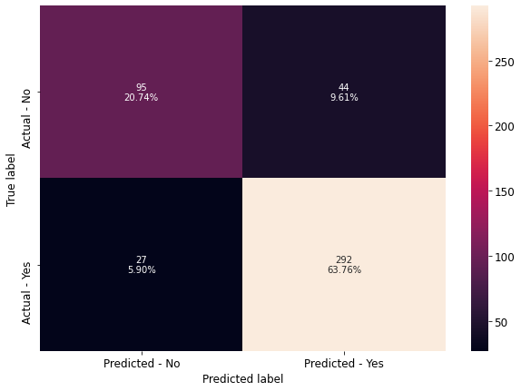

```python
make_confusion_matrix(best_grid_ada,y_test)
```

```
AUC Training Data for AdaBoost(tuned): 0.922
```

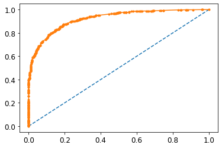

```
AUC Test Data for AdaBoost(tuned): 0.901
```

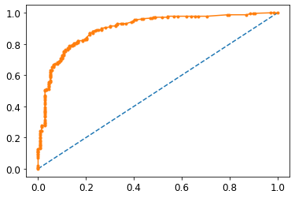

```python
# --------------------------------------------------------------------------------------------------------------------
# predict probabilities
probs_best_grid_ada = best_grid_ada.predict_proba(X_train)
# keep probabilities for the positive outcome only
probs_best_grid_ada = probs_best_grid_ada[:, 1]
# calculate AUC
auc_best_grid_ada_train = roc_auc_score(y_train, probs_best_grid_ada)
print('AUC Training Data for AdaBoost(tuned): %.3f' % auc_best_grid_ada_train)
# calculate ROC
fpr_best_grid_ada_train, tpr_best_grid_ada_train, thresholds_best_grid_ada_train = roc_curve(y_train, probs_best_grid_ada)
plt.plot([0, 1], [0, 1], linestyle='--')
# plot the roc curve for the model
plt.plot(fpr_best_grid_ada_train, tpr_best_grid_ada_train, marker='.')
# show the plot
plt.show()
# --------------------------------------------------------------------------------------------------------------------
# predict probabilities
probs_best_grid_ada = best_grid_ada.predict_proba(X_test)
# keep probabilities for the positive outcome only
probs_best_grid_ada = probs_best_grid_ada[:, 1]
# calculate AUC
auc_best_grid_ada_test = roc_auc_score(y_test, probs_best_grid_ada)
print('AUC Test Data for AdaBoost(tuned): %.3f' % auc_best_grid_ada_test)
# calculate ROC
fpr_best_grid_ada_test, tpr_best_grid_ada_test, thresholds_best_grid_ada_test = roc_curve(y_test, probs_best_grid_ada)
plt.plot([0, 1], [0, 1], linestyle='--')
# plot the roc curve for the model
plt.plot(fpr_best_grid_ada_test, tpr_best_grid_ada_test, marker='.')
# show the plot
plt.show()
```

```python
# defining list of models
models = [ada,best_grid_ada]

# defining empty lists to add train and test results
acc_train = []
acc_test = []
recall_train = []
recall_test = []
precision_train = []
precision_test = []
f1_train = []
f1_test = []

# looping through all the models to get the accuracy, precall and precision scores
for model in models:
    j = get_metrics_score(model,False)
    acc_train.append(np.round(j[0],2))
    acc_test.append(np.round(j[1],2))
    recall_train.append(np.round(j[2],2))
    recall_test.append(np.round(j[3],2))
    precision_train.append(np.round(j[4],2))
    precision_test.append(np.round(j[5],2))
    f1_train.append(np.round(j[6],2))
    f1_test.append(np.round(j[7],2))
```

```python
model_interpretation_frame = pd.DataFrame({'Model':['Adaboost','Adaboost (Tuned)'],
                                          'Train_Accuracy': acc_train,'Test_Accuracy': acc_test,
                                          'Train_Recall':recall_train,'Test_Recall':recall_test,
                                          'Train_Precision':precision_train,'Test_Precision':precision_test,
                                          'Train_F1 score':f1_train,'Test_F1 score':f1_test})
model_interpretation_frame
```

|  | Model | Train_Accuracy | Test_Accuracy | Train_Recall | Test_Recall | Train_Precision | Test_Precision | Train_F1 score | Test_F1 score |
| --- | --- | --- | --- | --- | --- | --- | --- | --- | --- |
| 0 | Adaboost | 0.83 | 0.84 | 0.91 | 0.93 | 0.86 | 0.86 | 0.88 | 0.89 |
| 1 | Adaboost (Tuned) | 0.86 | 0.84 | 0.92 | 0.92 | 0.88 | 0.87 | 0.90 | 0.89 |

**Intepretation:**

**AdaBoost (Tuned):**

- After model tuning, we don't see much improvement performance metrics parameters..

### Gradient Boosting (Model Tuning: init)

- Most of the hyperparameters available are same as random forest classifier.
- init: An estimator object that is used to compute the initial predictions. If ‘zero’, the initial raw predictions are set to zero. By default, a DummyEstimator predicting the classes priors is used.
- There is no class_weights parameter in gradient boosting.

**Let's try using AdaBoost classifier as the estimator for initial predictions**

```python
gbc_init = GradientBoostingClassifier(init=AdaBoostClassifier(random_state=1),random_state=1)
gbc_init.fit(X_train,y_train)
```

```
GradientBoostingClassifier(init=AdaBoostClassifier(random_state=1),
                           random_state=1)
```

```python
train_pred = gbc_init.predict(X_train)
test_pred = gbc_init.predict(X_test)

print('Train Accuracy: {:.0%}'.format(accuracy_score(y_train, train_pred)))
print('Test Accuracy: {:.0%}'.format(accuracy_score(y_test, test_pred)))
print('\n')
print("Train Classification Report")
print('\n')
print(classification_report(y_train, train_pred))
print("Test Classification Report")
print('\n')
print(classification_report(y_test, test_pred))
```

```
Train Accuracy: 89%
Test Accuracy: 84%


Train Classification Report


              precision    recall  f1-score   support

           0       0.85      0.77      0.81       323
           1       0.90      0.94      0.92       744

    accuracy                           0.89      1067
   macro avg       0.88      0.86      0.87      1067
weighted avg       0.89      0.89      0.89      1067

Test Classification Report


              precision    recall  f1-score   support

           0       0.77      0.67      0.72       139
           1       0.86      0.91      0.89       319

    accuracy                           0.84       458
   macro avg       0.82      0.79      0.80       458
weighted avg       0.83      0.84      0.84       458
```

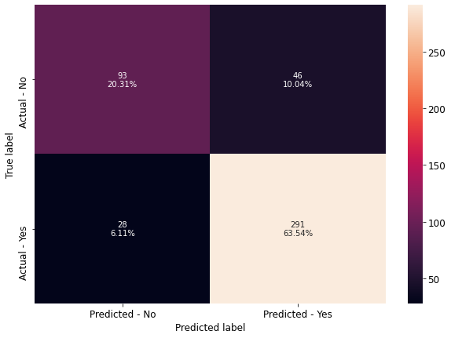

```python
make_confusion_matrix(gbc_init,y_test)
```

```
AUC Training Data for Logistic Regression(tuned): 0.949
```

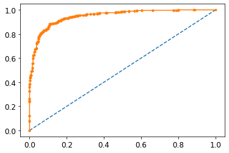

```
AUC Test Data for Logistic Regression(tuned): 0.909
```

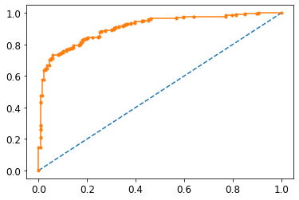

```python
# --------------------------------------------------------------------------------------------------------------------
# predict probabilities
probs_gbc_init = gbc_init.predict_proba(X_train)
# keep probabilities for the positive outcome only
probs_gbc_init = probs_gbc_init[:, 1]
# calculate AUC
auc_gbc_init_train = roc_auc_score(y_train, probs_gbc_init)
print('AUC Training Data for Logistic Regression(tuned): %.3f' % auc_gbc_init_train)
# calculate ROC
fpr_gbc_init_train, tpr_gbc_init_train, thresholds_gbc_init_train = roc_curve(y_train, probs_gbc_init)
plt.plot([0, 1], [0, 1], linestyle='--')
# plot the roc curve for the model
plt.plot(fpr_gbc_init_train, tpr_gbc_init_train, marker='.')
# show the plot
plt.show()
# --------------------------------------------------------------------------------------------------------------------
# predict probabilities
probs_gbc_init = gbc_init.predict_proba(X_test)
# keep probabilities for the positive outcome only
probs_gbc_init = probs_gbc_init[:, 1]
# calculate AUC
auc_gbc_init_test = roc_auc_score(y_test, probs_gbc_init)
print('AUC Test Data for Logistic Regression(tuned): %.3f' % auc_gbc_init_test)
# calculate ROC
fpr_gbc_init_test, tpr_gbc_init_test, thresholds_gbc_init_test = roc_curve(y_test, probs_gbc_init)
plt.plot([0, 1], [0, 1], linestyle='--')
# plot the roc curve for the model
plt.plot(fpr_gbc_init_test, tpr_gbc_init_test, marker='.')
# show the plot
plt.show()
```

```python
# defining list of models
models = [gbc,gbc_init]

# defining empty lists to add train and test results
acc_train = []
acc_test = []
recall_train = []
recall_test = []
precision_train = []
precision_test = []
f1_train = []
f1_test = []

# looping through all the models to get the accuracy, precall and precision scores
for model in models:
    j = get_metrics_score(model,False)
    acc_train.append(np.round(j[0],2))
    acc_test.append(np.round(j[1],2))
    recall_train.append(np.round(j[2],2))
    recall_test.append(np.round(j[3],2))
    precision_train.append(np.round(j[4],2))
    precision_test.append(np.round(j[5],2))
    f1_train.append(np.round(j[6],2))
    f1_test.append(np.round(j[7],2))
```

```python
model_interpretation_frame = pd.DataFrame({'Model':['Gradient Boosting','Gradient Boosting (init)'],
                                          'Train_Accuracy': acc_train,'Test_Accuracy': acc_test,
                                          'Train_Recall':recall_train,'Test_Recall':recall_test,
                                          'Train_Precision':precision_train,'Test_Precision':precision_test,
                                          'Train_F1 score':f1_train,'Test_F1 score':f1_test})
model_interpretation_frame
```

|  | Model | Train_Accuracy | Test_Accuracy | Train_Recall | Test_Recall | Train_Precision | Test_Precision | Train_F1 score | Test_F1 score |
| --- | --- | --- | --- | --- | --- | --- | --- | --- | --- |
| 0 | Gradient Boosting | 0.89 | 0.84 | 0.94 | 0.91 | 0.9 | 0.86 | 0.92 | 0.89 |
| 1 | Gradient Boosting (init) | 0.89 | 0.84 | 0.94 | 0.91 | 0.9 | 0.86 | 0.92 | 0.89 |

**Intepretation:**

**Gradient Boosting (Tuned: init parameter):**

- After model tuning, we don't see any improvement in performance metrics parameters.

### Gradient Boosting (Model Tuning)

```python
# define models and parameters
model = GradientBoostingClassifier(init=AdaBoostClassifier(random_state=1),random_state=1)

## Search grid for optimal parameters
gbc_param_grid = {
    "n_estimators": [100,150,200,250],
    "subsample":[0.7,0.8,0.9,1],
    "max_features":[0.7,0.8,0.9,1]
}


grid_search_gbc = GridSearchCV(model, param_grid = gbc_param_grid, cv=5,
                     n_jobs= -1, verbose = 1)

grid_search_gbc.fit(X_train,y_train)
```

```
Fitting 5 folds for each of 64 candidates, totalling 320 fits
```

```
GridSearchCV(cv=5,
             estimator=GradientBoostingClassifier(init=AdaBoostClassifier(random_state=1),
                                                  random_state=1),
             n_jobs=-1,
             param_grid={'max_features': [0.7, 0.8, 0.9, 1],
                         'n_estimators': [100, 150, 200, 250],
                         'subsample': [0.7, 0.8, 0.9, 1]},
             verbose=1)
```

```python
grid_search_gbc.best_params_
```

```
{'max_features': 1, 'n_estimators': 250, 'subsample': 0.9}
```

```python
best_grid_gbc = grid_search_gbc.best_estimator_
```

```python
train_pred = best_grid_gbc.predict(X_train)
test_pred = best_grid_gbc.predict(X_test)

print('Train Accuracy: {:.0%}'.format(accuracy_score(y_train, train_pred)))
print('Test Accuracy: {:.0%}'.format(accuracy_score(y_test, test_pred)))
print('\n')
print("Train Classification Report")
print('\n')
print(classification_report(y_train, train_pred))
print("Test Classification Report")
print('\n')
print(classification_report(y_test, test_pred))
```

```
Train Accuracy: 91%
Test Accuracy: 84%


Train Classification Report


              precision    recall  f1-score   support

           0       0.88      0.82      0.85       323
           1       0.92      0.95      0.94       744

    accuracy                           0.91      1067
   macro avg       0.90      0.89      0.89      1067
weighted avg       0.91      0.91      0.91      1067

Test Classification Report


              precision    recall  f1-score   support

           0       0.75      0.68      0.72       139
           1       0.87      0.90      0.88       319

    accuracy                           0.84       458
   macro avg       0.81      0.79      0.80       458
weighted avg       0.83      0.84      0.83       458
```

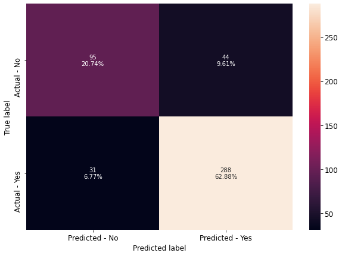

```python
make_confusion_matrix(best_grid_gbc,y_test)
```

```
AUC Training Data for Gradient Boosting(tuned): 0.956
```

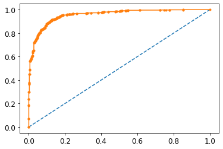

```
AUC Test Data for Gradient Boosting(tuned): 0.907
```

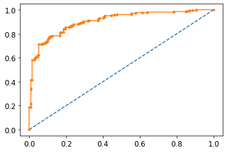

```python
# --------------------------------------------------------------------------------------------------------------------
# predict probabilities
probs_best_grid_gbc = best_grid_gbc.predict_proba(X_train)
# keep probabilities for the positive outcome only
probs_best_grid_gbc = probs_best_grid_gbc[:, 1]
# calculate AUC
auc_best_grid_gbc_train = roc_auc_score(y_train, probs_best_grid_gbc)
print('AUC Training Data for Gradient Boosting(tuned): %.3f' % auc_best_grid_gbc_train)
# calculate ROC
fpr_best_grid_gbc_train, tpr_best_grid_gbc_train, thresholds_best_grid_gbc_train = roc_curve(y_train, probs_best_grid_gbc)
plt.plot([0, 1], [0, 1], linestyle='--')
# plot the roc curve for the model
plt.plot(fpr_best_grid_gbc_train, tpr_best_grid_gbc_train, marker='.')
# show the plot
plt.show()
# --------------------------------------------------------------------------------------------------------------------
# predict probabilities
probs_best_grid_gbc = best_grid_gbc.predict_proba(X_test)
# keep probabilities for the positive outcome only
probs_best_grid_gbc = probs_best_grid_gbc[:, 1]
# calculate AUC
auc_best_grid_gbc_test = roc_auc_score(y_test, probs_best_grid_gbc)
print('AUC Test Data for Gradient Boosting(tuned): %.3f' % auc_best_grid_gbc_test)
# calculate ROC
fpr_best_grid_gbc_test, tpr_best_grid_gbc_test, thresholds_best_grid_gbc_test = roc_curve(y_test, probs_best_grid_gbc)
plt.plot([0, 1], [0, 1], linestyle='--')
# plot the roc curve for the model
plt.plot(fpr_best_grid_gbc_test, tpr_best_grid_gbc_test, marker='.')
# show the plot
plt.show()
```

```python
# defining list of models
models = [gbc_init,best_grid_gbc]

# defining empty lists to add train and test results
acc_train = []
acc_test = []
recall_train = []
recall_test = []
precision_train = []
precision_test = []
f1_train = []
f1_test = []

# looping through all the models to get the accuracy, precall and precision scores
for model in models:
    j = get_metrics_score(model,False)
    acc_train.append(np.round(j[0],2))
    acc_test.append(np.round(j[1],2))
    recall_train.append(np.round(j[2],2))
    recall_test.append(np.round(j[3],2))
    precision_train.append(np.round(j[4],2))
    precision_test.append(np.round(j[5],2))
    f1_train.append(np.round(j[6],2))
    f1_test.append(np.round(j[7],2))
```

```python
model_interpretation_frame = pd.DataFrame({'Model':['Gradient Boosting (init)',
                                                    'Gradient Boosting (Tuned)'],
                                          'Train_Accuracy': acc_train,'Test_Accuracy': acc_test,
                                          'Train_Recall':recall_train,'Test_Recall':recall_test,
                                          'Train_Precision':precision_train,'Test_Precision':precision_test,
                                          'Train_F1 score':f1_train,'Test_F1 score':f1_test})
model_interpretation_frame
```

|  | Model | Train_Accuracy | Test_Accuracy | Train_Recall | Test_Recall | Train_Precision | Test_Precision | Train_F1 score | Test_F1 score |
| --- | --- | --- | --- | --- | --- | --- | --- | --- | --- |
| 0 | Gradient Boosting (init) | 0.89 | 0.84 | 0.94 | 0.91 | 0.90 | 0.86 | 0.92 | 0.89 |
| 1 | Gradient Boosting (Tuned) | 0.91 | 0.84 | 0.95 | 0.90 | 0.92 | 0.87 | 0.94 | 0.88 |

**Intepretation:**

**Gradient Boosting (Tuned):**

- After model tuning, we could see overfit has increased.

### XGBoost (Model Tuning)

```python
# define models and parameters
model = XGBClassifier(random_state=1)

## Search grid for optimal parameters
xgb_param_grid = {
    "n_estimators": np.arange(10,100,20),
    "scale_pos_weight":[0,1,2],
    "subsample":[0.5,0.7],
    "learning_rate":[0.01,0.1,0.2,0.05],
    "gamma":[0,1],
    "colsample_bytree":[0.5,0.7,0.9,1],
    "colsample_bylevel":[0.5,0.7,0.9,1]
}


grid_search_xgb = GridSearchCV(model, param_grid = xgb_param_grid, cv=5,
                     n_jobs= -1, verbose = 1)

grid_search_xgb.fit(X_train,y_train)
```

```
Fitting 5 folds for each of 3840 candidates, totalling 19200 fits
[10:26:34] WARNING: C:/Users/Administrator/workspace/xgboost-win64_release_1.4.0/src/learner.cc:1095: Starting in XGBoost 1.3.0, the default evaluation metric used with the objective 'binary:logistic' was changed from 'error' to 'logloss'. Explicitly set eval_metric if you'd like to restore the old …
```

```
GridSearchCV(cv=5,
             estimator=XGBClassifier(base_score=None, booster=None,
                                     colsample_bylevel=None,
                                     colsample_bynode=None,
                                     colsample_bytree=None, gamma=None,
                                     gpu_id=None, importance_type='gain',
                                     interaction_constraints=None,
                                     learning_rate=None, max_delta_step=None,
                                     max_depth=None, min_child_weight=None,
                                     missing=nan, monotone_constraints=None,
                                     n_estimators=100, n_jobs...
                                     reg_alpha=None, reg_lambda=None,
                                     scale_pos_weight=None, subsample=None,
                                     tree_method=None, validate_parameters=None,
                                     verbosity=None),
             n_jobs=-1,
             param_grid={'colsample_bylevel': [0.5, 0.7, 0.9, 1],
                         'colsample_bytree': [0.5, 0.7, 0.9, 1],
                         'gamma': [0, 1],
                         'learning_rate': [0.01, 0.1, 0.2, 0.05],
                         'n_estimators': array([10, 30, 50, 70, 90]),
                         'scale_pos_weight': [0, 1, 2],
                         'subsample': [0.5, 0.7]},
             verbose=1)
```

```python
grid_search_xgb.best_params_
```

```
{'colsample_bylevel': 0.5,
 'colsample_bytree': 1,
 'gamma': 1,
 'learning_rate': 0.2,
 'n_estimators': 30,
 'scale_pos_weight': 1,
 'subsample': 0.5}
```

```python
best_grid_xgb = grid_search_xgb.best_estimator_
```

```python
train_pred = best_grid_xgb.predict(X_train)
test_pred = best_grid_xgb.predict(X_test)

print('Train Accuracy: {:.0%}'.format(accuracy_score(y_train, train_pred)))
print('Test Accuracy: {:.0%}'.format(accuracy_score(y_test, test_pred)))
print('\n')
print("Train Classification Report")
print('\n')
print(classification_report(y_train, train_pred))
print("Test Classification Report")
print('\n')
print(classification_report(y_test, test_pred))
```

```
Train Accuracy: 90%
Test Accuracy: 84%


Train Classification Report


              precision    recall  f1-score   support

           0       0.86      0.80      0.83       323
           1       0.92      0.94      0.93       744

    accuracy                           0.90      1067
   macro avg       0.89      0.87      0.88      1067
weighted avg       0.90      0.90      0.90      1067

Test Classification Report


              precision    recall  f1-score   support

           0       0.75      0.70      0.72       139
           1       0.87      0.90      0.88       319

    accuracy                           0.84       458
   macro avg       0.81      0.80      0.80       458
weighted avg       0.83      0.84      0.83       458
```

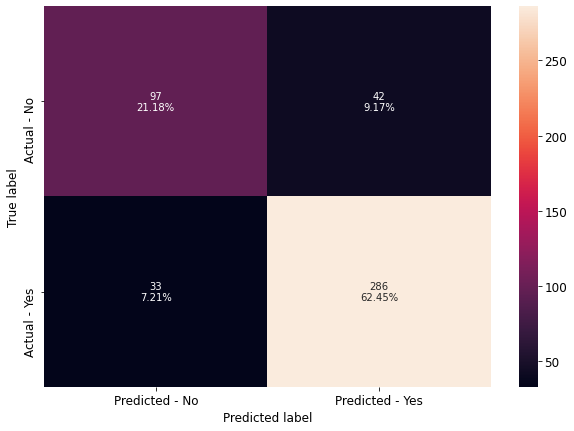

```python
make_confusion_matrix(best_grid_xgb,y_test)
```

```
AUC Training Data for XGBoost(tuned): 0.955
```

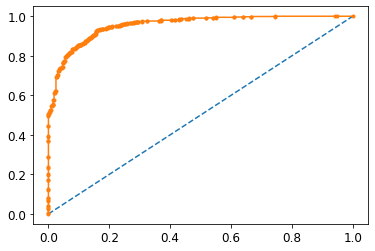

```
AUC Test Data for XGBoost(tuned): 0.906
```

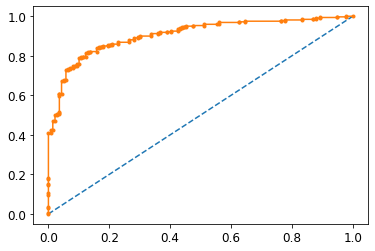

```python
# --------------------------------------------------------------------------------------------------------------------
# predict probabilities
probs_best_grid_xgb = best_grid_xgb.predict_proba(X_train)
# keep probabilities for the positive outcome only
probs_best_grid_xgb = probs_best_grid_xgb[:, 1]
# calculate AUC
auc_best_grid_xgb_train = roc_auc_score(y_train, probs_best_grid_xgb)
print('AUC Training Data for XGBoost(tuned): %.3f' % auc_best_grid_xgb_train)
# calculate ROC
fpr_best_grid_xgb_train, tpr_best_grid_xgb_train, thresholds_best_grid_xgb_train = roc_curve(y_train, probs_best_grid_xgb)
plt.plot([0, 1], [0, 1], linestyle='--')
# plot the roc curve for the model
plt.plot(fpr_best_grid_xgb_train, tpr_best_grid_xgb_train, marker='.')
# show the plot
plt.show()
# --------------------------------------------------------------------------------------------------------------------
# predict probabilities
probs_best_grid_xgb = best_grid_xgb.predict_proba(X_test)
# keep probabilities for the positive outcome only
probs_best_grid_xgb = probs_best_grid_xgb[:, 1]
# calculate AUC
auc_best_grid_xgb_test = roc_auc_score(y_test, probs_best_grid_xgb)
print('AUC Test Data for XGBoost(tuned): %.3f' % auc_best_grid_xgb_test)
# calculate ROC
fpr_best_grid_xgb_test, tpr_best_grid_xgb_test, thresholds_best_grid_xgb_test = roc_curve(y_test, probs_best_grid_xgb)
plt.plot([0, 1], [0, 1], linestyle='--')
# plot the roc curve for the model
plt.plot(fpr_best_grid_xgb_test, tpr_best_grid_xgb_test, marker='.')
# show the plot
plt.show()
```

```python
# defining list of models
models = [xgb,best_grid_xgb]

# defining empty lists to add train and test results
acc_train = []
acc_test = []
recall_train = []
recall_test = []
precision_train = []
precision_test = []
f1_train = []
f1_test = []

# looping through all the models to get the accuracy, precall and precision scores
for model in models:
    j = get_metrics_score(model,False)
    acc_train.append(np.round(j[0],2))
    acc_test.append(np.round(j[1],2))
    recall_train.append(np.round(j[2],2))
    recall_test.append(np.round(j[3],2))
    precision_train.append(np.round(j[4],2))
    precision_test.append(np.round(j[5],2))
    f1_train.append(np.round(j[6],2))
    f1_test.append(np.round(j[7],2))
```

```python
model_interpretation_frame = pd.DataFrame({'Model':['XGBoost',
                                                    'XGBoost (Tuned)'],
                                          'Train_Accuracy': acc_train,'Test_Accuracy': acc_test,
                                          'Train_Recall':recall_train,'Test_Recall':recall_test,
                                          'Train_Precision':precision_train,'Test_Precision':precision_test,
                                          'Train_F1 score':f1_train,'Test_F1 score':f1_test})
model_interpretation_frame
```

|  | Model | Train_Accuracy | Test_Accuracy | Train_Recall | Test_Recall | Train_Precision | Test_Precision | Train_F1 score | Test_F1 score |
| --- | --- | --- | --- | --- | --- | --- | --- | --- | --- |
| 0 | XGBoost | 0.99 | 0.83 | 1.00 | 0.9 | 0.99 | 0.86 | 0.99 | 0.88 |
| 1 | XGBoost (Tuned) | 0.90 | 0.84 | 0.94 | 0.9 | 0.92 | 0.87 | 0.93 | 0.88 |

**Intepretation:**

**XGBoost (Tuned):**

- After model tuning, we could see improvement in overfit and model looks promising.

### SVM (Model Tuning)

```python
# define models and parameters
model = svm.SVC(random_state=1,probability=True)

## Search grid for optimal parameters
svm_param_grid = {'C': [0.1,1, 10, 100],
                  'gamma': [1,0.1,0.01,0.001],
                  'kernel': ['rbf']}


grid_search_svm = GridSearchCV(model, param_grid = svm_param_grid, refit = True,
                     n_jobs= -1, verbose = 3)

grid_search_svm.fit(X_train,y_train)
```

```
Fitting 5 folds for each of 16 candidates, totalling 80 fits
```

```
GridSearchCV(estimator=SVC(probability=True, random_state=1), n_jobs=-1,
             param_grid={'C': [0.1, 1, 10, 100], 'gamma': [1, 0.1, 0.01, 0.001],
                         'kernel': ['rbf']},
             verbose=3)
```

```python
grid_search_svm.best_params_
```

```
{'C': 10, 'gamma': 0.01, 'kernel': 'rbf'}
```

```python
best_grid_svm = grid_search_svm.best_estimator_
```

```python
train_pred = best_grid_svm.predict(X_train)
test_pred = best_grid_svm.predict(X_test)

print('Train Accuracy: {:.0%}'.format(accuracy_score(y_train, train_pred)))
print('Test Accuracy: {:.0%}'.format(accuracy_score(y_test, test_pred)))
print('\n')
print("Train Classification Report")
print('\n')
print(classification_report(y_train, train_pred))
print("Test Classification Report")
print('\n')
print(classification_report(y_test, test_pred))
```

```
Train Accuracy: 84%
Test Accuracy: 85%


Train Classification Report


              precision    recall  f1-score   support

           0       0.77      0.65      0.70       323
           1       0.86      0.92      0.89       744

    accuracy                           0.84      1067
   macro avg       0.82      0.78      0.80      1067
weighted avg       0.83      0.84      0.83      1067

Test Classification Report


              precision    recall  f1-score   support

           0       0.81      0.68      0.74       139
           1       0.87      0.93      0.90       319

    accuracy                           0.85       458
   macro avg       0.84      0.80      0.82       458
weighted avg       0.85      0.85      0.85       458
```

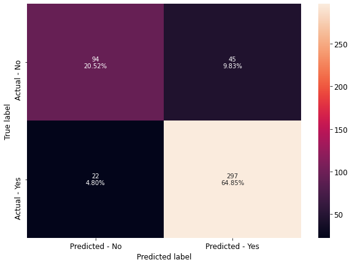

```python
make_confusion_matrix(best_grid_svm,y_test)
```

```
AUC Training Data for SVM(tuned): 0.904
```

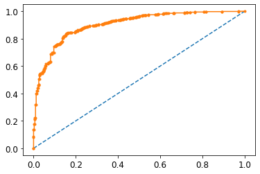

```
AUC Test Data for SVM(tuned): 0.916
```

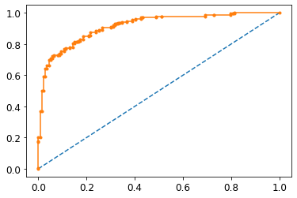

```python
# --------------------------------------------------------------------------------------------------------------------
# predict probabilities
probs_best_grid_svm = best_grid_svm.predict_proba(X_train)
# keep probabilities for the positive outcome only
probs_best_grid_svm = probs_best_grid_svm[:, 1]
# calculate AUC
auc_best_grid_svm_train = roc_auc_score(y_train, probs_best_grid_svm)
print('AUC Training Data for SVM(tuned): %.3f' % auc_best_grid_svm_train)
# calculate ROC
fpr_best_grid_svm_train, tpr_best_grid_svm_train, thresholds_best_grid_svm_train = roc_curve(y_train, probs_best_grid_svm)
plt.plot([0, 1], [0, 1], linestyle='--')
# plot the roc curve for the model
plt.plot(fpr_best_grid_svm_train, tpr_best_grid_svm_train, marker='.')
# show the plot
plt.show()
# --------------------------------------------------------------------------------------------------------------------
# predict probabilities
probs_best_grid_svm = best_grid_svm.predict_proba(X_test)
# keep probabilities for the positive outcome only
probs_best_grid_svm = probs_best_grid_svm[:, 1]
# calculate AUC
auc_best_grid_svm_test = roc_auc_score(y_test, probs_best_grid_svm)
print('AUC Test Data for SVM(tuned): %.3f' % auc_best_grid_svm_test)
# calculate ROC
fpr_best_grid_svm_test, tpr_best_grid_svm_test, thresholds_best_grid_svm_test = roc_curve(y_test, probs_best_grid_svm)
plt.plot([0, 1], [0, 1], linestyle='--')
# plot the roc curve for the model
plt.plot(fpr_best_grid_svm_test, tpr_best_grid_svm_test, marker='.')
# show the plot
plt.show()
```

```python
# defining list of models
models = [svm_model,best_grid_svm]

# defining empty lists to add train and test results
acc_train = []
acc_test = []
recall_train = []
recall_test = []
precision_train = []
precision_test = []
f1_train = []
f1_test = []

# looping through all the models to get the accuracy, precall and precision scores
for model in models:
    j = get_metrics_score(model,False)
    acc_train.append(np.round(j[0],2))
    acc_test.append(np.round(j[1],2))
    recall_train.append(np.round(j[2],2))
    recall_test.append(np.round(j[3],2))
    precision_train.append(np.round(j[4],2))
    precision_test.append(np.round(j[5],2))
    f1_train.append(np.round(j[6],2))
    f1_test.append(np.round(j[7],2))
```

```python
model_interpretation_frame = pd.DataFrame({'Model':['SVM',
                                                    'SVM (Tuned)'],
                                          'Train_Accuracy': acc_train,'Test_Accuracy': acc_test,
                                          'Train_Recall':recall_train,'Test_Recall':recall_test,
                                          'Train_Precision':precision_train,'Test_Precision':precision_test,
                                          'Train_F1 score':f1_train,'Test_F1 score':f1_test})
model_interpretation_frame
```

|  | Model | Train_Accuracy | Test_Accuracy | Train_Recall | Test_Recall | Train_Precision | Test_Precision | Train_F1 score | Test_F1 score |
| --- | --- | --- | --- | --- | --- | --- | --- | --- | --- |
| 0 | SVM | 0.83 | 0.85 | 0.92 | 0.93 | 0.86 | 0.87 | 0.89 | 0.9 |
| 1 | SVM (Tuned) | 0.84 | 0.85 | 0.92 | 0.93 | 0.86 | 0.87 | 0.89 | 0.9 |

**Intepretation:**

**SVM (Tuned):**

- After model tuning, we could see no improvement.

## Model Comparison

### All Models (Performance Metrics)

```python
# defining list of models
models = [lr,lda,knn,nb,bag,ada,gbc,xgb,svm_model,best_grid_lr,best_grid_lda,best_grid_knn,best_grid_nb,
          best_grid_bag,best_grid_ada,gbc_init,best_grid_gbc,best_grid_xgb,best_grid_svm]

# defining empty lists to add train and test results
acc_train = []
acc_test = []
recall_train = []
recall_test = []
precision_train = []
precision_test = []
f1_train = []
f1_test = []

# looping through all the models to get the accuracy, precall and precision scores
for model in models:
    j = get_metrics_score(model,False)
    acc_train.append(np.round(j[0],2))
    acc_test.append(np.round(j[1],2))
    recall_train.append(np.round(j[2],2))
    recall_test.append(np.round(j[3],2))
    precision_train.append(np.round(j[4],2))
    precision_test.append(np.round(j[5],2))
    f1_train.append(np.round(j[6],2))
    f1_test.append(np.round(j[7],2))
```

```python
model_interpretation_frame = pd.DataFrame({'Model':['Logistic Regression','LDA','KNN','Naive Bayes','Bagging',
                                                    'AdaBoost','Gradient Boosting','XGBoost','Support Vector Machine(SVM)',
                                                   'Logistic Regression(tuned)','LDA(tuned)','KNN(tuned)','Naive Bayes(tuned)',
                                                    'Bagging(tuned)','AdaBoost(tuned)','Gradient Boosting(init)',
                                                    'Gradient Boosting(tuned)','XGBoost(tuned)','SVM(tuned)'],
                                          'Train_Accuracy': acc_train,'Test_Accuracy': acc_test,
                                          'Train_Recall':recall_train,'Test_Recall':recall_test,
                                          'Train_Precision':precision_train,'Test_Precision':precision_test,
                                          'Train_F1 score':f1_train,'Test_F1 score':f1_test})
model_interpretation_frame
```

|  | Model | Train_Accuracy | Test_Accuracy | Train_Recall | Test_Recall | Train_Precision | Test_Precision | Train_F1 score | Test_F1 score |
| --- | --- | --- | --- | --- | --- | --- | --- | --- | --- |
| 0 | Logistic Regression | 0.83 | 0.85 | 0.91 | 0.92 | 0.86 | 0.87 | 0.88 | 0.90 |
| 1 | LDA | 0.83 | 0.84 | 0.90 | 0.91 | 0.86 | 0.87 | 0.88 | 0.89 |
| 2 | KNN | 0.86 | 0.84 | 0.91 | 0.91 | 0.89 | 0.87 | 0.90 | 0.89 |
| 3 | Naive Bayes | 0.82 | 0.85 | 0.88 | 0.90 | 0.87 | 0.88 | 0.87 | 0.89 |
| 4 | Bagging | 0.96 | 0.83 | 0.99 | 0.92 | 0.96 | 0.85 | 0.97 | 0.89 |
| 5 | AdaBoost | 0.83 | 0.84 | 0.91 | 0.93 | 0.86 | 0.86 | 0.88 | 0.89 |
| 6 | Gradient Boosting | 0.89 | 0.84 | 0.94 | 0.91 | 0.90 | 0.86 | 0.92 | 0.89 |
| 7 | XGBoost | 0.99 | 0.83 | 1.00 | 0.90 | 0.99 | 0.86 | 0.99 | 0.88 |
| 8 | Support Vector Machine(SVM) | 0.83 | 0.85 | 0.92 | 0.93 | 0.86 | 0.87 | 0.89 | 0.90 |
| 9 | Logistic Regression(tuned) | 0.83 | 0.85 | 0.91 | 0.92 | 0.86 | 0.87 | 0.88 | 0.90 |
| 10 | LDA(tuned) | 0.83 | 0.84 | 0.90 | 0.91 | 0.86 | 0.87 | 0.88 | 0.89 |
| 11 | KNN(tuned) | 0.84 | 0.86 | 0.90 | 0.92 | 0.87 | 0.88 | 0.89 | 0.90 |
| 12 | Naive Bayes(tuned) | 0.82 | 0.84 | 0.88 | 0.90 | 0.87 | 0.88 | 0.87 | 0.89 |
| 13 | Bagging(tuned) | 0.87 | 0.85 | 0.92 | 0.92 | 0.89 | 0.87 | 0.91 | 0.89 |
| 14 | AdaBoost(tuned) | 0.86 | 0.84 | 0.92 | 0.92 | 0.88 | 0.87 | 0.90 | 0.89 |
| 15 | Gradient Boosting(init) | 0.89 | 0.84 | 0.94 | 0.91 | 0.90 | 0.86 | 0.92 | 0.89 |
| 16 | Gradient Boosting(tuned) | 0.91 | 0.84 | 0.95 | 0.90 | 0.92 | 0.87 | 0.94 | 0.88 |
| 17 | XGBoost(tuned) | 0.90 | 0.84 | 0.94 | 0.90 | 0.92 | 0.87 | 0.93 | 0.88 |
| 18 | SVM(tuned) | 0.84 | 0.85 | 0.92 | 0.93 | 0.86 | 0.87 | 0.89 | 0.90 |

```python
model_interpretation_frame.to_excel('temp.xlsx')
```

### All Models (AUC-ROC)

#### Train Data

```
AUC Training Data for Logistic Regression: 0.877
AUC Training Data for LDA: 0.876
AUC Training Data for KNN: 0.933
AUC Training Data for Naive Bayes: 0.874
AUC Training Data for Bagging: 0.995
AUC Training Data for AdaBoost: 0.891
AUC Training Data for Gradient Boosting: 0.948
AUC Training Data for XGBoost: 0.999
AUC Training Data for SVM: 0.898
AUC Training Data for Logistic Regression(tuned): 0.877
AUC Training Data for LDA(tuned): 0.876
AUC Training Data for KNN(tuned): 0.907
AUC Training Data for Naive Bayes(tuned): 0.874
AUC Training Data for Bagging(tuned): 0.926
AUC Training Data for AdaBoost(tuned): 0.922
AUC Training Data for Gradient Boosting(init): 0.949
AUC Training Data for Gradient Boosting(tuned): 0.956
AUC Training Data for XGBoost(tuned): 0.955
AUC Training Data for SVM(tuned): 0.904
```

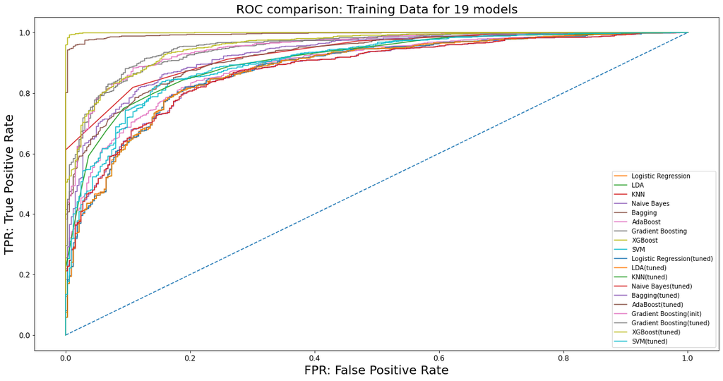

```python
#print AUC values of 19 models : Training Data
print('AUC Training Data for Logistic Regression: %.3f' % auc_lr_train)
print('AUC Training Data for LDA: %.3f' % auc_lda_train)
print('AUC Training Data for KNN: %.3f' % auc_knn_train)
print('AUC Training Data for Naive Bayes: %.3f' % auc_nb_train)
print('AUC Training Data for Bagging: %.3f' % auc_bag_train)
print('AUC Training Data for AdaBoost: %.3f' % auc_ada_train)
print('AUC Training Data for Gradient Boosting: %.3f' % auc_gbc_train)
print('AUC Training Data for XGBoost: %.3f' % auc_xgb_train)
print('AUC Training Data for SVM: %.3f' % auc_svm_train)
print('AUC Training Data for Logistic Regression(tuned): %.3f' % auc_best_grid_lr_train)
print('AUC Training Data for LDA(tuned): %.3f' % auc_best_grid_lda_train)
print('AUC Training Data for KNN(tuned): %.3f' % auc_best_grid_knn_train)
print('AUC Training Data for Naive Bayes(tuned): %.3f' % auc_best_grid_nb_train)
print('AUC Training Data for Bagging(tuned): %.3f' % auc_best_grid_bag_train)
print('AUC Training Data for AdaBoost(tuned): %.3f' % auc_best_grid_ada_train)
print('AUC Training Data for Gradient Boosting(init): %.3f' % auc_gbc_init_train)
print('AUC Training Data for Gradient Boosting(tuned): %.3f' % auc_best_grid_gbc_train)
print('AUC Training Data for XGBoost(tuned): %.3f' % auc_best_grid_xgb_train)
print('AUC Training Data for SVM(tuned): %.3f' % auc_best_grid_svm_train)

plt.figure(figsize=(20,10))
plt.plot([0, 1], [0, 1], linestyle='--')

plt.plot(fpr_lr_train, tpr_lr_train,label="Logistic Regression")
plt.plot(fpr_lda_train, tpr_lda_train,label="LDA")
plt.plot(fpr_knn_train, tpr_knn_train,label="KNN")
plt.plot(fpr_nb_train, tpr_nb_train,label="Naive Bayes")
plt.plot(fpr_bag_train, tpr_bag_train,label="Bagging")
plt.plot(fpr_ada_train, tpr_ada_train,label="AdaBoost")
plt.plot(fpr_gbc_train, tpr_gbc_train,label="Gradient Boosting")
plt.plot(fpr_xgb_train, tpr_xgb_train,label="XGBoost")
plt.plot(fpr_svm_train, tpr_svm_train,label="SVM")
plt.plot(fpr_best_grid_lr_train, tpr_best_grid_lr_train,label="Logistic Regression(tuned)")
plt.plot(fpr_best_grid_lda_train, tpr_best_grid_lda_train,label="LDA(tuned)")
plt.plot(fpr_best_grid_knn_train, tpr_best_grid_knn_train,label="KNN(tuned)")
plt.plot(fpr_best_grid_nb_train, tpr_best_grid_nb_train,label="Naive Bayes(tuned)")
plt.plot(fpr_best_grid_bag_train, tpr_best_grid_bag_train,label="Bagging(tuned)")
plt.plot(fpr_best_grid_ada_train, tpr_best_grid_ada_train,label="AdaBoost(tuned)")
plt.plot(fpr_gbc_init_train, tpr_gbc_init_train,label="Gradient Boosting(init)")
plt.plot(fpr_best_grid_gbc_train, tpr_best_grid_gbc_train,label="Gradient Boosting(tuned)")
plt.plot(fpr_best_grid_xgb_train, tpr_best_grid_xgb_train,label="XGBoost(tuned)")
plt.plot(fpr_best_grid_svm_train, tpr_best_grid_svm_train,label="SVM(tuned)")

plt.xlabel('FPR: False Positive Rate',fontsize=20)
plt.ylabel('TPR: True Positive Rate',fontsize=20)
plt.title("ROC comparison: Training Data for 19 models",fontsize=20)
plt.legend(fontsize=10)
# show the plot
plt.show()
```

#### Test Data

```
AUC Testing Data for Logistic Regression: 0.914
AUC Testing Data for LDA: 0.915
AUC Testing Data for KNN: 0.877
AUC Testing Data for Naive Bayes: 0.910
AUC Testing Data for Bagging: 0.916
AUC Testing Data for AdaBoost: 0.905
AUC Testing Data for Gradient Boosting: 0.908
AUC Testing Data for XGBoost: 0.881
AUC Testing Data for SVM: 0.915
AUC Testing Data for Logistic Regression(tuned): 0.914
AUC Testing Data for LDA(tuned): 0.915
AUC Testing Data for KNN(tuned): 0.902
AUC Testing Data for Naive Bayes(tuned): 0.910
AUC Testing Data for Bagging(tuned): 0.912
AUC Testing Data for AdaBoost(tuned): 0.901
AUC Testing Data for Gradient Boosting(init): 0.909
AUC Testing Data for Gradient Boosting(tuned): 0.907
AUC Testing Data for XGBoost(tuned): 0.906
AUC Testing Data for SVM(tuned): 0.916
```

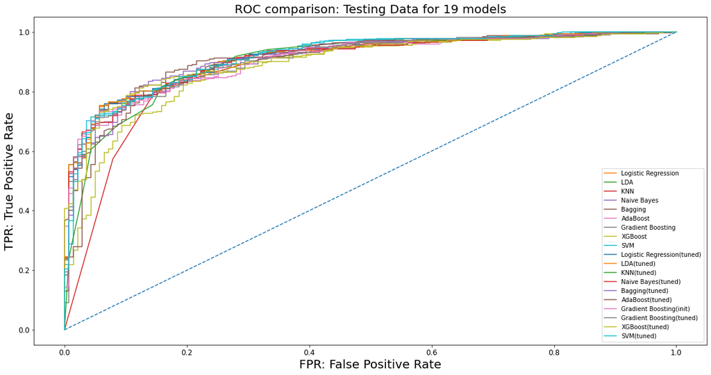

```python
#print AUC values of 19 models : Testing Data
print('AUC Testing Data for Logistic Regression: %.3f' % auc_lr_test)
print('AUC Testing Data for LDA: %.3f' % auc_lda_test)
print('AUC Testing Data for KNN: %.3f' % auc_knn_test)
print('AUC Testing Data for Naive Bayes: %.3f' % auc_nb_test)
print('AUC Testing Data for Bagging: %.3f' % auc_bag_test)
print('AUC Testing Data for AdaBoost: %.3f' % auc_ada_test)
print('AUC Testing Data for Gradient Boosting: %.3f' % auc_gbc_test)
print('AUC Testing Data for XGBoost: %.3f' % auc_xgb_test)
print('AUC Testing Data for SVM: %.3f' % auc_svm_test)
print('AUC Testing Data for Logistic Regression(tuned): %.3f' % auc_best_grid_lr_test)
print('AUC Testing Data for LDA(tuned): %.3f' % auc_best_grid_lda_test)
print('AUC Testing Data for KNN(tuned): %.3f' % auc_best_grid_knn_test)
print('AUC Testing Data for Naive Bayes(tuned): %.3f' % auc_best_grid_nb_test)
print('AUC Testing Data for Bagging(tuned): %.3f' % auc_best_grid_bag_test)
print('AUC Testing Data for AdaBoost(tuned): %.3f' % auc_best_grid_ada_test)
print('AUC Testing Data for Gradient Boosting(init): %.3f' % auc_gbc_init_test)
print('AUC Testing Data for Gradient Boosting(tuned): %.3f' % auc_best_grid_gbc_test)
print('AUC Testing Data for XGBoost(tuned): %.3f' % auc_best_grid_xgb_test)
print('AUC Testing Data for SVM(tuned): %.3f' % auc_best_grid_svm_test)

plt.figure(figsize=(20,10))
plt.plot([0, 1], [0, 1], linestyle='--')

plt.plot(fpr_lr_test, tpr_lr_test,label="Logistic Regression")
plt.plot(fpr_lda_test, tpr_lda_test,label="LDA")
plt.plot(fpr_knn_test, tpr_knn_test,label="KNN")
plt.plot(fpr_nb_test, tpr_nb_test,label="Naive Bayes")
plt.plot(fpr_bag_test, tpr_bag_test,label="Bagging")
plt.plot(fpr_ada_test, tpr_ada_test,label="AdaBoost")
plt.plot(fpr_gbc_test, tpr_gbc_test,label="Gradient Boosting")
plt.plot(fpr_xgb_test, tpr_xgb_test,label="XGBoost")
plt.plot(fpr_svm_test, tpr_svm_test,label="SVM")
plt.plot(fpr_best_grid_lr_test, tpr_best_grid_lr_test,label="Logistic Regression(tuned)")
plt.plot(fpr_best_grid_lda_test, tpr_best_grid_lda_test,label="LDA(tuned)")
plt.plot(fpr_best_grid_knn_test, tpr_best_grid_knn_test,label="KNN(tuned)")
plt.plot(fpr_best_grid_nb_test, tpr_best_grid_nb_test,label="Naive Bayes(tuned)")
plt.plot(fpr_best_grid_bag_test, tpr_best_grid_bag_test,label="Bagging(tuned)")
plt.plot(fpr_best_grid_ada_test, tpr_best_grid_ada_test,label="AdaBoost(tuned)")
plt.plot(fpr_gbc_init_test, tpr_gbc_init_test,label="Gradient Boosting(init)")
plt.plot(fpr_best_grid_gbc_test, tpr_best_grid_gbc_test,label="Gradient Boosting(tuned)")
plt.plot(fpr_best_grid_xgb_test, tpr_best_grid_xgb_test,label="XGBoost(tuned)")
plt.plot(fpr_best_grid_svm_test, tpr_best_grid_svm_test,label="SVM(tuned)")

plt.xlabel('FPR: False Positive Rate',fontsize=20)
plt.ylabel('TPR: True Positive Rate',fontsize=20)
plt.title("ROC comparison: Testing Data for 19 models",fontsize=20)
plt.legend(fontsize=10)
# show the plot
plt.show()
```

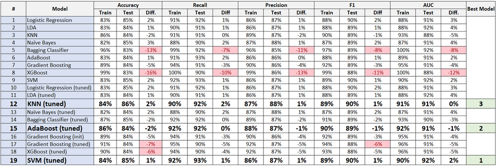

# Inference & Insights

**Inferences:**

1. In this dataset we have used total of 19 models including tuning (main 9 models).
2. It was great exposure understanding all the models and its hyper tuning parameters in details.
3. Further, we also found that border class imbalance dataset could also be treated with same distribution.
4. We tried applying SMOTE as well in the dataset and evaluated the result based on F1-score and precision and we found:
   - Slight change in performance metrics parameters BUT found more overfit and underfit even thought applying multiple iterations in hyper tuning in Grid Search.
   - Hence, it proved that slight class imbalance (i.e. 4:6 OR 3:7) could be processed with AS IS.

**Insights:**

1. A Cost Function quantifies the error between predicted values and expected values and presents it in the form of a single real number.
2. The voting prediction model could be choose depending on their cost function which they want to minimize. The cost function can depend on the geographical and economic conditions as well.
3. Main aim would be to balance the trade-off between losing an opportunity (to gain vote by getting right publicity and work) in case of FP and losing the votes in case of FN.
4. Based on above model’s poll comes out that “labour” party will get the higher seats than “conventional” and top3 models which would help to predict are:
   - SVM OR SVM (tuned)
   - AdaBoost (tuned)
   - KNN (tuned)